# Анализ оттока клиентов в банке

# Описание исследования

В нашем распоряжении данные о клиентах банка «Метанпром». Банк располагается в Ярославле и областных городах: Ростов Великий и Рыбинск.

[Ссылка на презентацию](https://drive.google.com/file/d/12vqDRcreZ53c2v8BzlQn5sWdd0GkT-nc/view)

# Цель исследования

Максимально эффективно выделить сегменты отточных клиентов, чтобы они были однородными, высокоотточными и покрывали максимум проблемных зон банка. Таким образом, маркетинговое воздействие на эти сегменты должно привести к уменьшению оттока.

# Задачи исследования

1. Оценить представленные данные.
2. Выполнить предобработку данных.
3. Провести исследовательский анализ данных, включающий исследование корреляций и портретов клиентов.
4. Выделить не мелкие, но компактные высокоотточные сегменты, приоритизировать их.
5. Сформулировать выводы и сделать базовые рекомендации по работе с клиентами.
6. Подготовить презентацию со всеми ключевыми моментами.

# Исходные данные

В нашем распоряжении один датасет. Файл bank_scrooge.csv содержит данные о клиентах банка «Метанпром». Структура файла bank_scrooge.csv:

```
userid — идентификатор клиента,
score — балл кредитного скоринга клиента,
city — город представительства банка,
gender — пол,
age — возраст,
equity — количество баллов собственности,
balance — баланс на счёте,
products — количество продуктов, которыми пользуется клиент,
credit_card — наличие кредитной карты у клиента,
last_activity — наличие активности клиента,
est_salary — оценочный доход клиента,
сhurn — факт оттока.
```

# Содержание исследования

## Загрузка данных и подготовка к исследованию

### Импортируем необходимые библиотеки

```python
!pip install phik -q
import phik
import pandas as pd
import numpy as np
import collections
import matplotlib.pyplot as plt
import matplotlib.ticker as ticker
from matplotlib.ticker import MultipleLocator
import seaborn as sns
import plotly.express as px
import plotly.graph_objects as go
from plotly.subplots import make_subplots
import plotly.io as pio
from IPython.display import Image
from scipy import stats as st
import scipy.stats as stats
import warnings
import re
```

### Cчитаем данные из csv-файла в датафрейм и сохраним в переменной data

```python
data = pd.read_csv(r'C:\Users\Равиль\Проекты для портфолио\4. Анализ оттока клиентов в банке\bank_scrooge.csv')
```

### Изучим общую информацию о датафрейме data

```python
data.head(10)
```

|  | USERID | score | city | gender | age | equity | balance | products | credit_card | last_activity | EST_SALARY | churn |
| --- | --- | --- | --- | --- | --- | --- | --- | --- | --- | --- | --- | --- |
| 0 | 183012 | 850.0 | Рыбинск | Ж | 25.0 | 1 | 59214.82 | 2 | 0 | 1 | 75719.14 | 1 |
| 1 | 146556 | 861.0 | Рыбинск | Ж | 37.0 | 5 | 850594.33 | 3 | 1 | 0 | 86621.77 | 0 |
| 2 | 120722 | 892.0 | Рыбинск | Ж | 30.0 | 0 | NaN | 1 | 1 | 1 | 107683.34 | 0 |
| 3 | 225363 | 866.0 | Ярославль | Ж | 51.0 | 5 | 1524746.26 | 2 | 0 | 1 | 174423.53 | 1 |
| 4 | 157978 | 730.0 | Ярославль | М | 34.0 | 5 | 174.00 | 1 | 1 | 0 | 67353.16 | 1 |
| 5 | 202305 | 856.0 | Рыбинск | М | 56.0 | 4 | 863687.24 | 3 | 1 | 0 | 156619.80 | 0 |
| 6 | 177259 | 807.0 | Ярославль | Ж | 39.0 | 3 | 405042.44 | 3 | 0 | 1 | 103838.32 | 0 |
| 7 | 218868 | 825.0 | Ярославль | Ж | 38.0 | 4 | 458145.40 | 2 | 1 | 1 | 68085.48 | 0 |
| 8 | 211686 | 923.0 | Ярославль | М | 54.0 | 5 | 1206337.87 | 2 | 1 | 0 | 155371.79 | 0 |
| 9 | 133130 | 906.0 | Ярославль | Ж | 67.0 | 0 | NaN | 1 | 0 | 1 | 238055.53 | 0 |

### Выведем основную информацию о датафрейме data

```python
data.info()
```

```
<class 'pandas.core.frame.DataFrame'>
RangeIndex: 10000 entries, 0 to 9999
Data columns (total 12 columns):
 #   Column         Non-Null Count  Dtype
---  ------         --------------  -----
 0   USERID         10000 non-null  int64
 1   score          10000 non-null  float64
 2   city           10000 non-null  object
 3   gender         10000 non-null  object
 4   age            9974 non-null   float64
 5   equity         10000 non-null  int64
 6   balance        7705 non-null   float64
 7   products       10000 non-null  int64
 8   credit_card    10000 non-null  int64
 9   last_activity  10000 non-null  int64
 10  EST_SALARY     10000 non-null  float64
 11  churn          10000 non-null  int64
dtypes: float64(4), int64(6), object(2)
memory usage: 937.6+ KB
```

### Оценим какие уникальные значения есть в столбце score датафрейма data

```python
sorted(data['score'].unique())[:15]
```

```
[642.0,
 646.0,
 648.0,
 649.0,
 650.0,
 651.0,
 652.0,
 653.0,
 654.0,
 655.0,
 656.0,
 657.0,
 658.0,
 659.0,
 660.0]
```

### Оценим какие уникальные значения есть в столбце age датафрейма data

```python
sorted(data['age'].unique())[:15]
```

```
[18.0,
 19.0,
 20.0,
 21.0,
 22.0,
 23.0,
 24.0,
 25.0,
 26.0,
 27.0,
 28.0,
 29.0,
 30.0,
 31.0,
 32.0]
```

### Оценим какой минимальный и максимальный баланс на счёте предствален в датафрейме data

```python
pd.options.display.float_format = '{:,.2f}'.format
data[['balance']].agg(['min', 'max'])
```

|  | balance |
| --- | --- |
| min | 0.00 |
| max | 119,113,552.01 |

### Оценим какой совокупный баланс на счёте клиентов предствален в датафрейме data

```python
balance_sum = data['balance'].sum()
formatted_balance = '{:,.2f}'.format(balance_sum)
formatted_balance
```

```
'6,378,155,131.66'
```

### Создадим функци format_float, которая будет считать сумму по столбцу и разделять вывод на разряды

```python
def format_float(dataset, column1):
    balance_sum = dataset[column1].sum()
    formatted_balance = '{:,.2f}'.format(balance_sum)
    print(formatted_balance)
```

### Оценим какой минимальный и максимальный оценочный доход клиента предствален в датафрейме data

```python
data[['EST_SALARY']].agg(['min', 'max'])
```

|  | EST_SALARY |
| --- | --- |
| min | 2,546.30 |
| max | 1,395,064.45 |

### Оценим какой совокупный оценочный доход клиентов предствален в датафрейме data, использую функцию format_float

```python
format_float(data, 'EST_SALARY')
```

```
1,478,668,855.44
```

### Выводы по первому разделу

Таблица data содежит 12 столбцов в которой имеются целые, вещественные числа и строки. Максимальный баланс на счете клиента составляет 119,113,552.01 рублей. Совокупный баланс на счетах клиентов составляет 6,378,155,131.66 рублей. Максимальны оценочный доход клиента составляет 1,395,064.45 рублей. Совокупный оценочный доход клиентов составляет 1,478,668,855.44 рублей. Названия некоторых столбцов таблицы data имеют заглавные буквы. Имеет смысл перевести их в нижний регистр. Столбцы score и age датафрейма data, содержат только целые числа и при этом имеют тип данных вещественных чисел. Имеет смысл перевести тип данных этих столбцов из вещественных чисел в целые.

## Предобработка данных

### Приведем к нижнему регистру названия столбцов датафрейма data и оценим результат

```python
data.columns = data.columns.str.lower()
data.head()
```

|  | userid | score | city | gender | age | equity | balance | products | credit_card | last_activity | est_salary | churn |
| --- | --- | --- | --- | --- | --- | --- | --- | --- | --- | --- | --- | --- |
| 0 | 183012 | 850.00 | Рыбинск | Ж | 25.00 | 1 | 59,214.82 | 2 | 0 | 1 | 75,719.14 | 1 |
| 1 | 146556 | 861.00 | Рыбинск | Ж | 37.00 | 5 | 850,594.33 | 3 | 1 | 0 | 86,621.77 | 0 |
| 2 | 120722 | 892.00 | Рыбинск | Ж | 30.00 | 0 | NaN | 1 | 1 | 1 | 107,683.34 | 0 |
| 3 | 225363 | 866.00 | Ярославль | Ж | 51.00 | 5 | 1,524,746.26 | 2 | 0 | 1 | 174,423.53 | 1 |
| 4 | 157978 | 730.00 | Ярославль | М | 34.00 | 5 | 174.00 | 1 | 1 | 0 | 67,353.16 | 1 |

### Обработка пропущенных значений

#### Опеределим сколько всего есть пропущенных значений в датафрейме data

```python
data.isna().sum().sort_values(ascending=False)
```

```
balance          2295
age                26
userid              0
score               0
city                0
gender              0
equity              0
products            0
credit_card         0
last_activity       0
est_salary          0
churn               0
dtype: int64
```

#### Оценим сколько пропущено значений в столбцах в процентах от общего количества

```python
round(data.isna().mean().sort_values(ascending=False) * 100, 2)
```

```
balance         22.95
age              0.26
userid           0.00
score            0.00
city             0.00
gender           0.00
equity           0.00
products         0.00
credit_card      0.00
last_activity    0.00
est_salary       0.00
churn            0.00
dtype: float64
```

#### Запишем количество строк датафрейма data в переменной len_data_before_del до обработки

```python
len_data_before_del = len(data)
len_data_before_del
```

```
10000
```

#### Оценим в каких строках есть пропущенные значения в столбце balance в датафрейме data

```python
data.loc[data['balance'].isna()].head(10)
```

|  | userid | score | city | gender | age | equity | balance | products | credit_card | last_activity | est_salary | churn |
| --- | --- | --- | --- | --- | --- | --- | --- | --- | --- | --- | --- | --- |
| 2 | 120722 | 892.00 | Рыбинск | Ж | 30.00 | 0 | NaN | 1 | 1 | 1 | 107,683.34 | 0 |
| 9 | 133130 | 906.00 | Ярославль | Ж | 67.00 | 0 | NaN | 1 | 0 | 1 | 238,055.53 | 0 |
| 10 | 148929 | 927.00 | Ростов | М | 52.00 | 0 | NaN | 1 | 1 | 1 | 196,820.07 | 0 |
| 11 | 172184 | 921.00 | Ростов | М | 41.00 | 0 | NaN | 1 | 1 | 1 | 217,469.48 | 0 |
| 19 | 127034 | 922.00 | Рыбинск | Ж | 53.00 | 0 | NaN | 1 | 0 | 0 | 147,094.82 | 0 |
| 21 | 177415 | 896.00 | Рыбинск | Ж | 47.00 | 0 | NaN | 1 | 0 | 0 | 225,060.35 | 0 |
| 30 | 155730 | 946.00 | Ярославль | Ж | 47.00 | 0 | NaN | 2 | 1 | 1 | 660,015.85 | 0 |
| 34 | 205226 | 944.00 | Ярославль | М | 35.00 | 0 | NaN | 2 | 1 | 1 | 239,843.39 | 0 |
| 39 | 173175 | 924.00 | Рыбинск | Ж | 51.00 | 0 | NaN | 1 | 1 | 1 | 248,844.47 | 0 |
| 43 | 228585 | 956.00 | Ростов | М | 41.00 | 0 | NaN | 1 | 1 | 0 | 115,117.10 | 0 |

#### Оценим в каких строках есть пропущенные значения в столбце age в датафрейме data

```python
missed_age = data.loc[data['age'].isna()].sort_values(by = 'balance', ascending = False)
missed_age.head(10)
```

|  | userid | score | city | gender | age | equity | balance | products | credit_card | last_activity | est_salary | churn |
| --- | --- | --- | --- | --- | --- | --- | --- | --- | --- | --- | --- | --- |
| 1247 | 228075 | 932.00 | Ярославль | М | NaN | 5 | 7,601,719.20 | 2 | 1 | 1 | 408,121.16 | 0 |
| 9667 | 163657 | 849.00 | Ярославль | М | NaN | 4 | 1,254,013.85 | 2 | 1 | 1 | 119,106.67 | 0 |
| 7236 | 210135 | 908.00 | Рыбинск | Ж | NaN | 4 | 1,120,340.31 | 3 | 1 | 1 | 85,002.15 | 0 |
| 9104 | 222480 | 776.00 | Рыбинск | Ж | NaN | 5 | 796,735.09 | 1 | 1 | 1 | 55,073.63 | 0 |
| 5470 | 218868 | 827.00 | Рыбинск | Ж | NaN | 4 | 448,959.07 | 2 | 1 | 1 | 67,835.95 | 0 |
| 9819 | 140934 | 832.00 | Рыбинск | Ж | NaN | 3 | 385,763.16 | 2 | 0 | 1 | 59,651.35 | 0 |
| 3091 | 138660 | 836.00 | Ростов | Ж | NaN | 5 | 294,315.53 | 2 | 0 | 1 | 63,310.22 | 1 |
| 4912 | 210674 | 834.00 | Рыбинск | М | NaN | 1 | 238,330.52 | 2 | 0 | 1 | 93,775.06 | 0 |
| 7345 | 184913 | 829.00 | Ярославль | Ж | NaN | 3 | 188,648.77 | 2 | 0 | 1 | 75,206.90 | 0 |
| 7409 | 214031 | 777.00 | Ярославль | М | NaN | 2 | 171,510.23 | 1 | 1 | 1 | 75,409.63 | 0 |

#### Оценим совокупный баланс на счетах клиентов у которых пропущены значения в столбце с возрастом, используя функцию format_float

```python
format_float(missed_age, 'balance')
```

```
12,500,335.73
```

#### Оценим долю в процентах совокупного баланса на счетах клиентов у которых пропущены значения в столбце с возрастом

```python
print(f"Доля совокупного баланса на счетах клиентов с пропущенным значениями в столбце \
возраста: {round((missed_age['balance'].sum() / data['balance'].sum() * 100), 2)}%.")
```

```
Доля совокупного баланса на счетах клиентов с пропущенным значениями в столбце возраста: 0.2%.
```

**Вывод:** Доля пропущенных значений в столбце с возрастом составляет 0.26 %. Доля совокупного баланса на счетах клиентов с пропущенным значениями в столбце возраста составляетс 0.2 %. С учетом этих данных принимаем решение удалить строки где пропущены значения в столбце с возрастом.

#### Удалим в датафремей data строки, где есть пропуски в столбце age и проверим результат удаления

```python
data = data.dropna(subset=['age'])
data['age'].isnull().sum()
```

```
0
```

#### Запишем количество строк датафрейма data в переменной len_data_after_del

```python
len_data_after_del = len(data)
len_data_after_del
```

```
9974
```

#### Оценим количество и долю удаленных данных в датафрейме data

```python
count_del_data = len_data_before_del - len_data_after_del
share_del_data = round(((len_data_before_del - len_data_after_del) / len_data_before_del)*100, 2)
print(f'Количество удаленных данных в датафрейме data: {count_del_data} или {share_del_data}%.')
```

```
Количество удаленных данных в датафрейме data: 26 или 0.26%.
```

### Проверка явных и неявных дубликатов

#### Проверим есть ли явные дубликаты в датафрейме data

```python
data.duplicated().sum()
```

```
0
```

#### Проверим есть ли явные дубликаты по столбцу userid

```python
data.duplicated(subset=['userid']).sum()
```

```
50
```

#### Оценим какие есть явные дубликаты по столбцу userid

```python
data[data.duplicated(subset=['userid'], keep=False)].sort_values(by = 'userid').head(10)
```

|  | userid | score | city | gender | age | equity | balance | products | credit_card | last_activity | est_salary | churn |
| --- | --- | --- | --- | --- | --- | --- | --- | --- | --- | --- | --- | --- |
| 1893 | 116540 | 883.00 | Рыбинск | Ж | 55.00 | 1 | 362,756.49 | 3 | 0 | 1 | 175,920.48 | 1 |
| 7694 | 116540 | 887.00 | Ярославль | Ж | 38.00 | 0 | NaN | 1 | 0 | 1 | 119,247.61 | 0 |
| 4866 | 117943 | 855.00 | Рыбинск | Ж | 32.00 | 6 | 1,036,832.93 | 4 | 1 | 1 | 107,792.71 | 1 |
| 7542 | 117943 | 880.00 | Ярославль | Ж | 40.00 | 0 | NaN | 1 | 1 | 0 | 137,718.93 | 0 |
| 5863 | 120258 | 908.00 | Рыбинск | Ж | 38.00 | 4 | 2,213,581.63 | 2 | 0 | 1 | 160,327.77 | 1 |
| 5896 | 120258 | 905.00 | Ярославль | М | 30.00 | 0 | NaN | 1 | 1 | 1 | 146,427.96 | 0 |
| 1411 | 123461 | 829.00 | Ярославль | Ж | 59.00 | 0 | 96,222.44 | 2 | 0 | 1 | 102,771.55 | 1 |
| 8638 | 123461 | 934.00 | Рыбинск | М | 34.00 | 0 | NaN | 2 | 1 | 0 | 291,619.27 | 0 |
| 9775 | 124450 | 758.00 | Рыбинск | Ж | 36.00 | 0 | 73,574.07 | 2 | 0 | 1 | 79,963.59 | 0 |
| 8164 | 124450 | 859.00 | Ярославль | Ж | 38.00 | 6 | 516,811.20 | 1 | 1 | 1 | 95,144.63 | 1 |

#### Оценим какие есть явные дубликаты по столбцам userid и city

```python
data.duplicated(subset=['userid', 'city']).sum()
```

```
0
```

### Приведение данных столбцов к нужному типу

#### Переведем значения столбца score датафрейма data из вещественных чисел в целые и оценим результат преобразования

```python
data['score'] = data['score'].astype('int')
data['score'].dtype
```

```
dtype('int32')
```

#### Переведем значения столбца age датафрейма data из вещественных чисел в целые и оценим результат преобразования

```python
data['age'] = data['age'].astype('int')
data['age'].dtype
```

```
dtype('int32')
```

### Выводы по предобработке данных

1. Были приведены к нижнему регистру названия столбцов датафрейма.
2. В исходном датафрейме с данными пропущены значения в столбцах баланс на счёте (2295 значений или 22.95%) и возраст age (26 значений или 0.26%). Пропусков в других столбцах в таблице нет. Наиболее вероятно, что пропуски в данных могли быть связаны с ошибкой из-за неправильного запроса или объединения таблиц на этапе выгрузки. Чтобы точно определить причины пропусков в данных, необходимо провести более детальный анализ данных и обратиться к источнику данных.
3. Были удалены строки с пропущенными значениями в столбце age. Всего удалено 26 строк, что составляет 0.26%.
4. В датафрейме нет явных дубликатов.
5. Дубликаты в столбце userid связаны с тем, что в датафрейме есть клиенты из города Рыбинска и Ярославля, которые имеют одинаковые идентификаторы. При этом мы считаем таких клиентов уникальными, так как они разного возраста, пола и имеют разные баллы кредитного скоринга.
6. Был переведен из типа вещественных чисел в целые столбцы score и age датафрейма.

## Исследовательский анализ данных

### Выведем описательную статистику по датафрему data

```python
data.describe().T
```

|  | count | mean | std | min | 25% | 50% | 75% | max |
| --- | --- | --- | --- | --- | --- | --- | --- | --- |
| userid | 9,974.00 | 171,755.22 | 33,695.53 | 94,561.00 | 142,760.00 | 172,643.00 | 201,163.75 | 229,145.00 |
| score | 9,974.00 | 848.68 | 65.40 | 642.00 | 802.00 | 853.00 | 900.00 | 1,000.00 |
| age | 9,974.00 | 42.73 | 12.18 | 18.00 | 33.00 | 40.00 | 51.00 | 86.00 |
| equity | 9,974.00 | 2.63 | 1.98 | 0.00 | 0.00 | 3.00 | 4.00 | 9.00 |
| balance | 7,695.00 | 827,245.59 | 1,980,327.41 | 0.00 | 295,698.71 | 524,295.33 | 980,051.21 | 119,113,552.01 |
| products | 9,974.00 | 1.87 | 0.79 | 0.00 | 1.00 | 2.00 | 2.00 | 5.00 |
| credit_card | 9,974.00 | 0.68 | 0.47 | 0.00 | 0.00 | 1.00 | 1.00 | 1.00 |
| last_activity | 9,974.00 | 0.52 | 0.50 | 0.00 | 0.00 | 1.00 | 1.00 | 1.00 |
| est_salary | 9,974.00 | 147,786.81 | 139,285.51 | 2,546.30 | 75,251.66 | 119,626.79 | 174,499.81 | 1,395,064.45 |
| churn | 9,974.00 | 0.18 | 0.39 | 0.00 | 0.00 | 0.00 | 0.00 | 1.00 |

### Оценим распределение ушедших и оставшихся клиентов по столбцу churn датафрейма data

```python
count_churn_1 = data['churn'][data['churn'] == 1].count()
count_churn_0 = data['churn'][data['churn'] == 0].count()
count_churn_1_percent = round((data['churn'][data['churn'] == 1].count() / len(data)) * 100, 2)
count_churn_0_percent = round((data['churn'][data['churn'] == 0].count() / len(data)) * 100, 2)
print(f'Количество ушедших клиентов: {count_churn_1} или {count_churn_1_percent} %.')
print(f'Количество оставшихся клиентов: {count_churn_0} или {count_churn_0_percent} %.')
```

```
Количество ушедших клиентов: 1819 или 18.24 %.
Количество оставшихся клиентов: 8155 или 81.76 %.
```

### Создадим функцию, которая будет считать количество клиентов и их долю в зависимости от признаков датафрйема data

```python
def count_of_data(dataset, column1, name1, name2, value1, value2):
    count_1 = dataset[column1][dataset[column1] == value1].count()
    count_2 = dataset[column1][dataset[column1] == value2].count()
    count_1_percent = round((dataset[column1][dataset[column1] == value1].count() / len(dataset)) * 100, 2)
    count_2_percent = round((dataset[column1][dataset[column1] == value2].count() / len(dataset)) * 100, 2)
    print(f'{name1}: {count_1} или {count_1_percent} %.')
    print(f'{name2}: {count_2} или {count_2_percent} %.')
```

### Оценим распределение мужчин и женщин по столбцу gender в датафрейме data, используя функцию count_of_data

```python
count_of_data(data, 'gender', 'Количество клиентов мужчин', 'Количество клиентов женщин', 'М', 'Ж')
```

```
Количество клиентов мужчин: 4991 или 50.04 %.
Количество клиентов женщин: 4983 или 49.96 %.
```

### Оценим распределение клиентов имеющих и не имеющих кредитные карты в датафрейме data, используя функцию count_of_data

```python
count_of_data(data, 'credit_card', 'Количество клиентов у которых есть кредитная карта', \
              'Количество клиентов у которых нет кредитной карты', 1, 0)
```

```
Количество клиентов у которых есть кредитная карта: 6784 или 68.02 %.
Количество клиентов у которых нет кредитной карты: 3190 или 31.98 %.
```

### Оценим распределение активных и неактивных клиентов в датафрейме data, используя функцию count_of_data

```python
count_of_data(data, 'last_activity', 'Количество активных клиентов', 'Количество неактивных клиентов', 1, 0)
```

```
Количество активных клиентов: 5215 или 52.29 %.
Количество неактивных клиентов: 4759 или 47.71 %.
```

```
city - город представительства банка;
count_city - количество клиентов по городам представительства банка;
count_city_percent - количество клиентов по городам представительства банка в процентах от общего количества.
```

```python
data_crosstab_city = pd.crosstab(index=data['city'], columns=['count_city']).reset_index()
data_crosstab_city['count_city_percent'] = round((data_crosstab_city['count_city'] / len(data)) * 100, 2)
data_crosstab_city = data_crosstab_city.sort_values(by='count_city', ascending=False).reset_index(drop=True)
data_crosstab_city
```

| col_0 | city | count_city | count_city_percent |
| --- | --- | --- | --- |
| 0 | Ярославль | 5875 | 58.90 |
| 1 | Рыбинск | 2683 | 26.90 |
| 2 | Ростов | 1416 | 14.20 |

### Создадим функцию crosstab_table, которая будет строить данную сводную таблицу в зависимости от изучаемого датафрейма

```python
def crosstab_table(dataset):
    data_crosstab = pd.crosstab(index=dataset['city'], columns=['count_city']).reset_index()
    data_crosstab['count_city_percent'] = round((data_crosstab['count_city'] / len(dataset)) * 100, 2)
    data_crosstab = data_crosstab.sort_values(by='count_city', ascending=False).reset_index(drop=True)
    return data_crosstab
```

### Построим график распределения клиентов по городам представительства банка

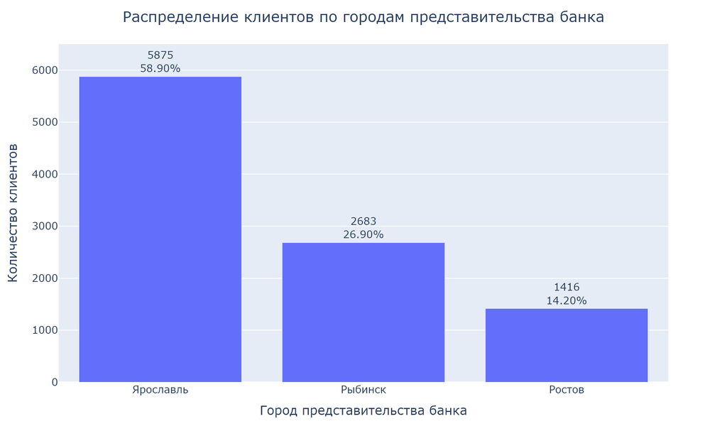

```python
data_crosstab_city['text'] = data_crosstab_city.apply(lambda x: \
                                               f'{x["count_city"]:.0f}<br>{x["count_city_percent"]:.2f}%', axis=1)
fig = px.bar(data_crosstab_city,
             x='city',
             y='count_city',
             text = 'text')
fig.update_layout(title='Распределение клиентов по городам представительства банка', title_x=0.5,
                  xaxis_title='Город представительства банка',
                  yaxis_title='Количество клиентов',
                  width=990,
                  height=600,
                  font_size=14)
fig.update_traces(textfont_size=14, textposition='outside')
fig.update_yaxes(range=[0, 6500])
pio.write_image(fig, 'Распределение клиентов по городам представительства банка.png', width=990, height=600, scale=2)
Image('Распределение клиентов по городам представительства банка.png')
```

### Создадим функцию make_plot, которая будет строить данный график в зависимости от изучаемого датафрейма и верхнего лимита оси y

```python
def make_plot(dataset, ylimit, title1):
    dataset['text'] = dataset.apply(lambda x:f'{x["count_city"]:.0f}<br>{x["count_city_percent"]:.2f}%', axis=1)
    fig = px.bar(dataset,
                 x='city',
                 y='count_city',
                 text = 'text')
    fig.update_layout(title=title1, title_x=0.5,
                      xaxis_title='Город представительства банка',
                      yaxis_title='Количество клиентов',
                      width=990,
                      height=600,
                      font_size=14)
    fig.update_traces(textfont_size=14, textposition='outside')
    fig.update_yaxes(range=[0, ylimit])
    filename = f"{title1}.png"
    pio.write_image(fig, filename, width=990, height=600, scale=2)
    return Image(filename)
```

### Описание портретов ушедших и оставшихся клиентов

#### Создадим отфильтрованный датафрейм filtered_data_churn, в котором выведем только ушедших клиентов

```python
filtered_data_churn = data.query('churn == 1').reset_index(drop=True)
filtered_data_churn.head(10)
```

|  | userid | score | city | gender | age | equity | balance | products | credit_card | last_activity | est_salary | churn |
| --- | --- | --- | --- | --- | --- | --- | --- | --- | --- | --- | --- | --- |
| 0 | 183012 | 850 | Рыбинск | Ж | 25 | 1 | 59,214.82 | 2 | 0 | 1 | 75,719.14 | 1 |
| 1 | 225363 | 866 | Ярославль | Ж | 51 | 5 | 1,524,746.26 | 2 | 0 | 1 | 174,423.53 | 1 |
| 2 | 157978 | 730 | Ярославль | М | 34 | 5 | 174.00 | 1 | 1 | 0 | 67,353.16 | 1 |
| 3 | 132970 | 845 | Ярославль | Ж | 31 | 3 | 591,928.52 | 2 | 1 | 1 | 112,697.16 | 1 |
| 4 | 129705 | 811 | Рыбинск | М | 34 | 2 | 129,799.35 | 1 | 0 | 0 | 96,242.71 | 1 |
| 5 | 210764 | 748 | Рыбинск | М | 46 | 2 | 182,889.96 | 1 | 1 | 1 | 74,009.18 | 1 |
| 6 | 164676 | 860 | Ярославль | М | 37 | 5 | 648,594.03 | 2 | 1 | 1 | 213,586.86 | 1 |
| 7 | 136096 | 896 | Ярославль | Ж | 39 | 5 | 657,597.09 | 2 | 0 | 1 | 266,033.98 | 1 |
| 8 | 156677 | 873 | Ярославль | М | 39 | 5 | 915,959.85 | 3 | 0 | 1 | 154,034.62 | 1 |
| 9 | 155403 | 859 | Рыбинск | М | 56 | 5 | 652,553.80 | 2 | 1 | 1 | 60,791.77 | 1 |

#### Выведем описательную статистику по датафрему filtered_data_churn

```python
filtered_data_churn.describe().T
```

|  | count | mean | std | min | 25% | 50% | 75% | max |
| --- | --- | --- | --- | --- | --- | --- | --- | --- |
| userid | 1,819.00 | 170,980.10 | 35,291.18 | 94,561.00 | 141,304.00 | 170,532.00 | 201,399.50 | 229,058.00 |
| score | 1,819.00 | 863.42 | 49.62 | 706.00 | 828.00 | 866.00 | 898.00 | 1,000.00 |
| age | 1,819.00 | 41.45 | 11.18 | 18.00 | 32.00 | 39.00 | 52.00 | 79.00 |
| equity | 1,819.00 | 3.76 | 1.59 | 0.00 | 3.00 | 4.00 | 5.00 | 9.00 |
| balance | 1,806.00 | 1,134,458.21 | 2,034,445.55 | 6.00 | 387,482.16 | 783,908.90 | 1,348,127.55 | 64,866,210.15 |
| products | 1,819.00 | 2.38 | 0.92 | 0.00 | 2.00 | 2.00 | 3.00 | 5.00 |
| credit_card | 1,819.00 | 0.55 | 0.50 | 0.00 | 0.00 | 1.00 | 1.00 | 1.00 |
| last_activity | 1,819.00 | 0.70 | 0.46 | 0.00 | 0.00 | 1.00 | 1.00 | 1.00 |
| est_salary | 1,819.00 | 148,289.70 | 122,932.16 | 10,880.27 | 83,196.61 | 125,395.22 | 175,985.39 | 1,263,028.49 |
| churn | 1,819.00 | 1.00 | 0.00 | 1.00 | 1.00 | 1.00 | 1.00 | 1.00 |

#### Оценим распределение мужчин и женщин по столбцу gender в датафрейме filtered_data_churn, используя функцию count_of_data

```python
count_of_data(filtered_data_churn, 'gender', 'Количество клиентов мужчин', 'Количество клиентов женщин', 'М', 'Ж')
```

```
Количество клиентов мужчин: 1183 или 65.04 %.
Количество клиентов женщин: 636 или 34.96 %.
```

#### Оценим распределение клиентов имеющих и не имеющих кредитные карты в датафрейме filtered_data_churn, используя функцию count_of_data

```python
count_of_data(filtered_data_churn, 'credit_card', 'Количество клиентов у которых есть кредитная карта', \
              'Количество клиентов у которых нет кредитной карты', 1, 0)
```

```
Количество клиентов у которых есть кредитная карта: 1003 или 55.14 %.
Количество клиентов у которых нет кредитной карты: 816 или 44.86 %.
```

#### Оценим распределение активных и неактивных клиентов в датафрейме filtered_data_churn, используя функцию count_of_data

```python
count_of_data(filtered_data_churn, 'last_activity', 'Количество активных клиентов', 'Количество неактивных клиентов', 1, 0)
```

```
Количество активных клиентов: 1277 или 70.2 %.
Количество неактивных клиентов: 542 или 29.8 %.
```

#### Создадим переменную data_crosstab_city_churn и присвоим ей результат выполнения функции crosstab_table для таблицы filtered_data_churn для оценки распределения ушедших клиентов по городам представительства банка

```python
data_crosstab_city_churn = crosstab_table(filtered_data_churn)
```

#### Построим график распределения ушедших клиентов по городам представительства банка, используя функцию make_plot для датафрейма data_crosstab_city_churn

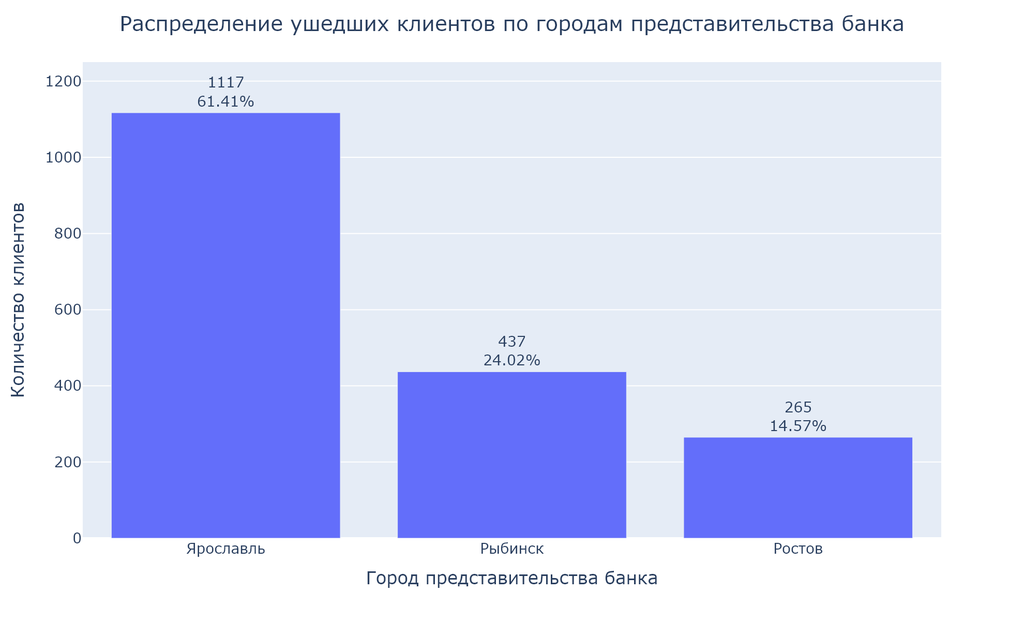

```python
make_plot(data_crosstab_city_churn, 1250, 'Распределение ушедших клиентов по городам представительства банка')
```

#### Создадим отфильтрованный датафрейм filtered_data_remain, в котором выведем только оставшихся клиентов

```python
filtered_data_remain = data.query('churn == 0').reset_index(drop=True)
filtered_data_remain.head(10)
```

|  | userid | score | city | gender | age | equity | balance | products | credit_card | last_activity | est_salary | churn |
| --- | --- | --- | --- | --- | --- | --- | --- | --- | --- | --- | --- | --- |
| 0 | 146556 | 861 | Рыбинск | Ж | 37 | 5 | 850,594.33 | 3 | 1 | 0 | 86,621.77 | 0 |
| 1 | 120722 | 892 | Рыбинск | Ж | 30 | 0 | NaN | 1 | 1 | 1 | 107,683.34 | 0 |
| 2 | 202305 | 856 | Рыбинск | М | 56 | 4 | 863,687.24 | 3 | 1 | 0 | 156,619.80 | 0 |
| 3 | 177259 | 807 | Ярославль | Ж | 39 | 3 | 405,042.44 | 3 | 0 | 1 | 103,838.32 | 0 |
| 4 | 218868 | 825 | Ярославль | Ж | 38 | 4 | 458,145.40 | 2 | 1 | 1 | 68,085.48 | 0 |
| 5 | 211686 | 923 | Ярославль | М | 54 | 5 | 1,206,337.87 | 2 | 1 | 0 | 155,371.79 | 0 |
| 6 | 133130 | 906 | Ярославль | Ж | 67 | 0 | NaN | 1 | 0 | 1 | 238,055.53 | 0 |
| 7 | 148929 | 927 | Ростов | М | 52 | 0 | NaN | 1 | 1 | 1 | 196,820.07 | 0 |
| 8 | 172184 | 921 | Ростов | М | 41 | 0 | NaN | 1 | 1 | 1 | 217,469.48 | 0 |
| 9 | 166357 | 837 | Рыбинск | Ж | 28 | 4 | 302,249.22 | 2 | 0 | 1 | 30,950.94 | 0 |

#### Выведем описательную статистику по датафрему filtered_data_remain

```python
filtered_data_remain.describe().T
```

|  | count | mean | std | min | 25% | 50% | 75% | max |
| --- | --- | --- | --- | --- | --- | --- | --- | --- |
| userid | 8,155.00 | 171,928.11 | 33,328.98 | 95,384.00 | 143,046.00 | 173,142.00 | 201,160.50 | 229,145.00 |
| score | 8,155.00 | 845.40 | 67.99 | 642.00 | 796.00 | 848.00 | 900.00 | 1,000.00 |
| age | 8,155.00 | 43.02 | 12.38 | 18.00 | 34.00 | 40.00 | 51.00 | 86.00 |
| equity | 8,155.00 | 2.38 | 1.97 | 0.00 | 0.00 | 3.00 | 4.00 | 9.00 |
| balance | 5,889.00 | 733,031.63 | 1,953,952.48 | 0.00 | 279,654.70 | 475,410.09 | 853,826.36 | 119,113,552.01 |
| products | 8,155.00 | 1.76 | 0.71 | 1.00 | 1.00 | 2.00 | 2.00 | 5.00 |
| credit_card | 8,155.00 | 0.71 | 0.45 | 0.00 | 0.00 | 1.00 | 1.00 | 1.00 |
| last_activity | 8,155.00 | 0.48 | 0.50 | 0.00 | 0.00 | 0.00 | 1.00 | 1.00 |
| est_salary | 8,155.00 | 147,674.64 | 142,684.41 | 2,546.30 | 73,445.55 | 118,227.60 | 173,960.92 | 1,395,064.45 |
| churn | 8,155.00 | 0.00 | 0.00 | 0.00 | 0.00 | 0.00 | 0.00 | 0.00 |

#### Оценим распределение мужчин и женщин по столбцу gender в датафрейме filtered_data_remain, используя функцию count_of_data

```python
count_of_data(filtered_data_remain, 'gender', 'Количество клиентов мужчин', 'Количество клиентов женщин', 'М', 'Ж')
```

```
Количество клиентов мужчин: 3808 или 46.7 %.
Количество клиентов женщин: 4347 или 53.3 %.
```

#### Оценим распределение клиентов имеющих и не имеющих кредитные карты в датафрейме filtered_data_remain, используя функцию count_of_data

```python
count_of_data(filtered_data_remain, 'credit_card', 'Количество клиентов у которых есть кредитная карта', \
              'Количество клиентов у которых нет кредитной карты', 1, 0)
```

```
Количество клиентов у которых есть кредитная карта: 5781 или 70.89 %.
Количество клиентов у которых нет кредитной карты: 2374 или 29.11 %.
```

#### Оценим распределение активных и неактивных клиентов в датафрейме filtered_data_remain, используя функцию count_of_data

```python
count_of_data(filtered_data_remain, 'last_activity', 'Количество активных клиентов', 'Количество неактивных клиентов',\
              1, 0)
```

```
Количество активных клиентов: 3938 или 48.29 %.
Количество неактивных клиентов: 4217 или 51.71 %.
```

#### Создадим переменную data_crosstab_city_remain и присвоим ей результат выполнения функции crosstab_table для таблицы filtered_data_remain для оценки распределения оставшихся клиентов по городам представительства банка

```python
data_crosstab_city_remain = crosstab_table(filtered_data_remain)
```

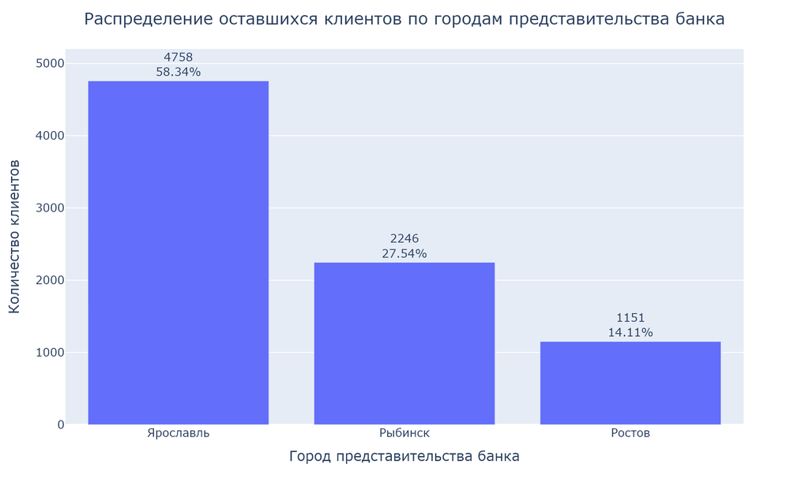

```python
make_plot(data_crosstab_city_remain, 5200, 'Распределение оставшихся клиентов по городам представительства банка')
```

### Построение столбчатых гистограмм по плотности распределения вероятностей для ушедших и оставшихся клиентов

#### Построим гистограмму плотности распределения вероятностей для ушедших и оставшихся клиентов по баллам кредитного скоринга

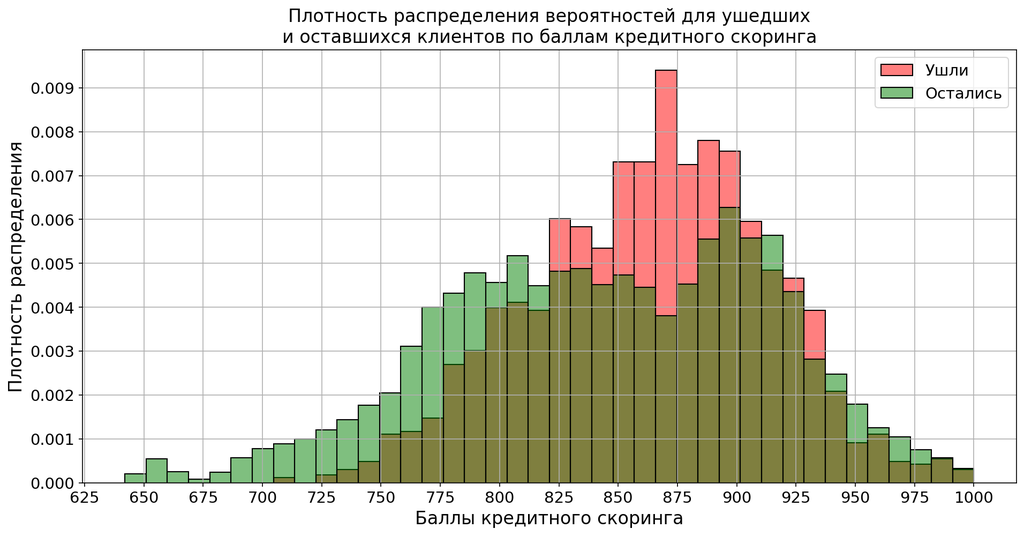

```python
plt.figure(figsize=(15, 7), dpi=150)
sns.histplot(data=data, hue='churn', x='score', stat='density', common_norm = False, palette={0: 'g', 1: 'r'})
plt.xticks(fontsize=14)
plt.yticks(fontsize=14)
plt.title('Плотность распределения вероятностей для ушедших\nи оставшихся клиентов по баллам кредитного скоринга',
          fontsize = 16)
plt.ylabel('Плотность распределения', fontsize = 16)
plt.xlabel('Баллы кредитного скоринга', fontsize = 16)
plt.gca().xaxis.set_major_locator(MultipleLocator(25))
plt.gca().yaxis.set_major_locator(MultipleLocator(0.001))
plt.legend(loc='upper right', bbox_to_anchor=(1, 1), frameon=True, fontsize=14, labels=['Ушли', 'Остались'])
plt.grid(True)
plt.show()
```

**Вывод:** Наиболее отточными являются клиенты, имеющие баллы кредитного скоринга от 820 до 900.

#### Построим гистограмму плотности распределения вероятностей для ушедших и оставшихся клиентов по городам представительства банка

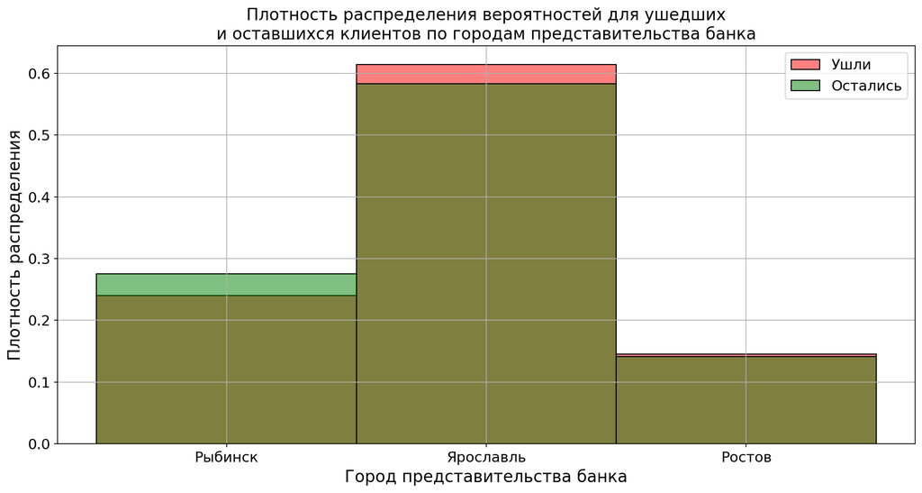

```python
plt.figure(figsize=(15, 7), dpi=150)
sns.histplot(data=data, hue='churn', x='city', discrete = True, stat='density', common_norm = False, palette={0: 'g',\
                                                                                                              1 :'r'})
plt.xticks(fontsize=14)
plt.yticks(fontsize=14)
plt.title('Плотность распределения вероятностей для ушедших\nи оставшихся клиентов по городам представительства банка',
          fontsize = 16)
plt.ylabel('Плотность распределения', fontsize = 16)
plt.xlabel('Город представительства банка', fontsize = 16)
plt.legend(loc='upper right', bbox_to_anchor=(1, 1), frameon=True, fontsize=14, labels=['Ушли', 'Остались'])
plt.grid(True)
plt.show()
```

**Вывод:** Наиболее отточными являются клиенты банка из его представительства в Ярославле.

#### Построим гистограмму плотности распределения вероятностей для ушедших и оставшихся клиентов по полу

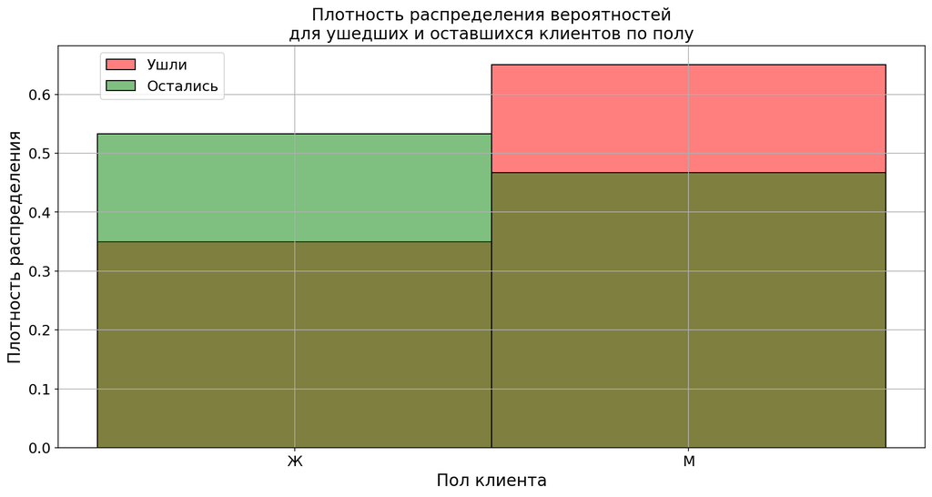

```python
plt.figure(figsize=(15, 7), dpi=150)
sns.histplot(data=data, hue='churn', x='gender', discrete = True, stat='density', common_norm = False, palette={0: 'g',\
                                                                                                                1: 'r'})
plt.xticks(fontsize=14)
plt.yticks(fontsize=14)
plt.title('Плотность распределения вероятностей\nдля ушедших и оставшихся клиентов по полу',
          fontsize = 16)
plt.ylabel('Плотность распределения', fontsize = 16)
plt.xlabel('Пол клиента', fontsize = 16)
plt.legend(loc='upper right', bbox_to_anchor=(0.2, 1), frameon=True, fontsize=14, labels=['Ушли', 'Остались'])
plt.grid(True)
plt.show()
```

**Вывод:** Наиболее отточными являются клиенты банка мужского пола.

#### Построим гистограмму плотности распределения вероятностей для ушедших и оставшихся клиентов по возрасту

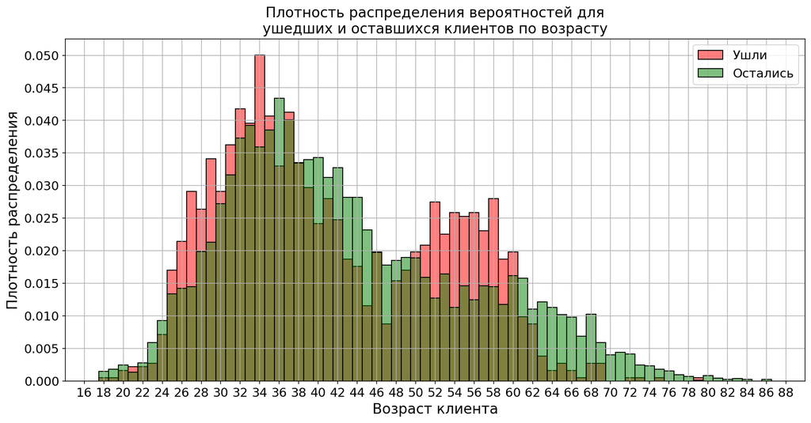

```python
plt.figure(figsize=(15, 7), dpi=150)
sns.histplot(data=data, hue='churn', x='age', discrete = True, stat='density', common_norm = False, palette={0: 'g',\
                                                                                                             1: 'r'})
plt.xticks(fontsize=14)
plt.yticks(fontsize=14)
plt.title('Плотность распределения вероятностей для\nушедших и оставшихся клиентов по возрасту',
          fontsize = 16)
plt.ylabel('Плотность распределения', fontsize = 16)
plt.xlabel('Возраст клиента', fontsize = 16)
plt.gca().xaxis.set_major_locator(MultipleLocator(2))
plt.gca().yaxis.set_major_locator(MultipleLocator(0.005))
plt.legend(loc='upper right', bbox_to_anchor=(1, 1), frameon=True, fontsize=14, labels=['Ушли', 'Остались'])
plt.grid(True)
plt.show()
```

**Вывод:** На основе возраста можно выделить 2 группы отточных клиентов. Это 25 - 35 лет и 50 - 60 лет.

#### Построим гистограмму плотности распределения вероятностей для ушедших и оставшихся клиентов по количеству баллов собственности

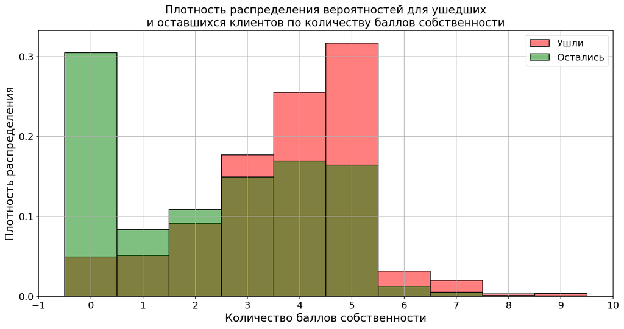

```python
plt.figure(figsize=(15, 7), dpi=150)
sns.histplot(data=data, hue='churn', x='equity', discrete = True, stat='density', common_norm = False, palette={0: 'g',\
                                                                                                                1: 'r'})
plt.xticks(fontsize=14)
plt.yticks(fontsize=14)
plt.title('Плотность распределения вероятностей для ушедших\nи оставшихся клиентов по количеству баллов собственности',
          fontsize = 16)
plt.ylabel('Плотность распределения', fontsize = 16)
plt.xlabel('Количество баллов собственности', fontsize = 16)
plt.gca().xaxis.set_major_locator(MultipleLocator(1))
plt.gca().yaxis.set_major_locator(MultipleLocator(0.1))
plt.legend(loc='upper right', bbox_to_anchor=(1, 1), frameon=True, fontsize=14, labels=['Ушли', 'Остались'])
plt.grid(True)
plt.show()
```

**Вывод:** Наиболее отточными являются клиенты, имеющие от 3 и более баллов собственности.

#### Построим гистограмму плотности распределения вероятностей для ушедших и оставшихся клиентов по балансу на счетах клиентов

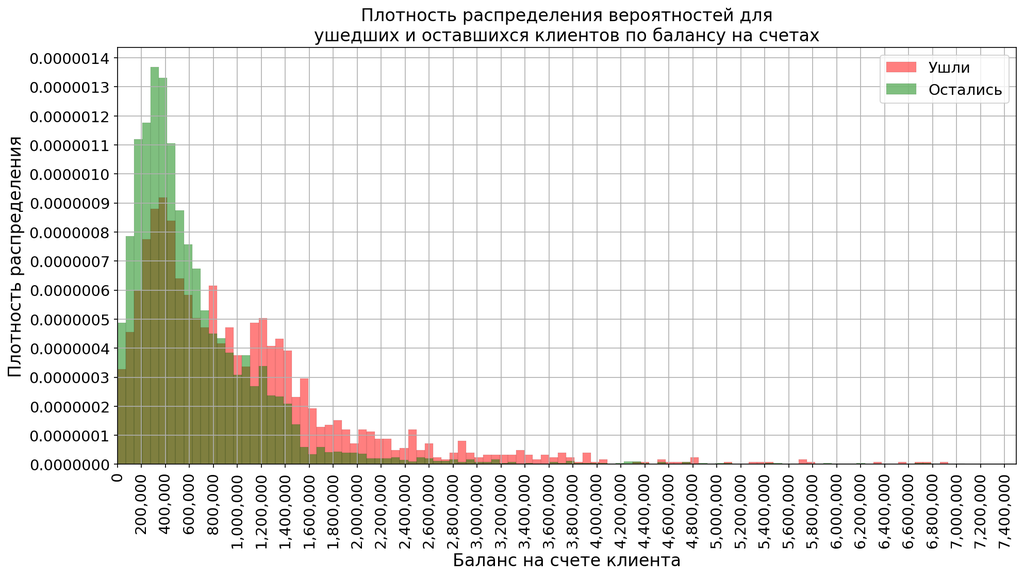

```python
plt.figure(figsize=(15, 7), dpi=150)
sns.histplot(data=data, hue='churn', x='balance', stat='density', common_norm = False, palette={0: 'g', 1: 'r'})
plt.xlim(0, 7500000)
plt.ticklabel_format(style='plain')
formatter = ticker.FuncFormatter(lambda x, _: '{:,.0f}'.format(x))
plt.gca().xaxis.set_major_formatter(formatter)
plt.xticks(fontsize=14, rotation = 90)
plt.yticks(fontsize=14)
plt.title('Плотность распределения вероятностей для\nушедших и оставшихся клиентов по балансу на счетах',
          fontsize = 16)
plt.ylabel('Плотность распределения', fontsize = 16)
plt.xlabel('Баланс на счете клиента', fontsize = 16)
plt.gca().xaxis.set_major_locator(MultipleLocator(200000))
plt.gca().yaxis.set_major_locator(MultipleLocator(0.0000001))
plt.legend(loc='upper right', bbox_to_anchor=(1, 1), frameon=True, fontsize=14, labels=['Ушли', 'Остались'])
plt.grid(True)
plt.show()
```

**Вывод:** Наиболее отточными являются клиенты, имеющие баланс на счете более 1 100 000 рублей.

#### Построим гистограмму плотности распределения вероятностей для ушедших и оставшихся клиентов по количество продуктов, используемых ими

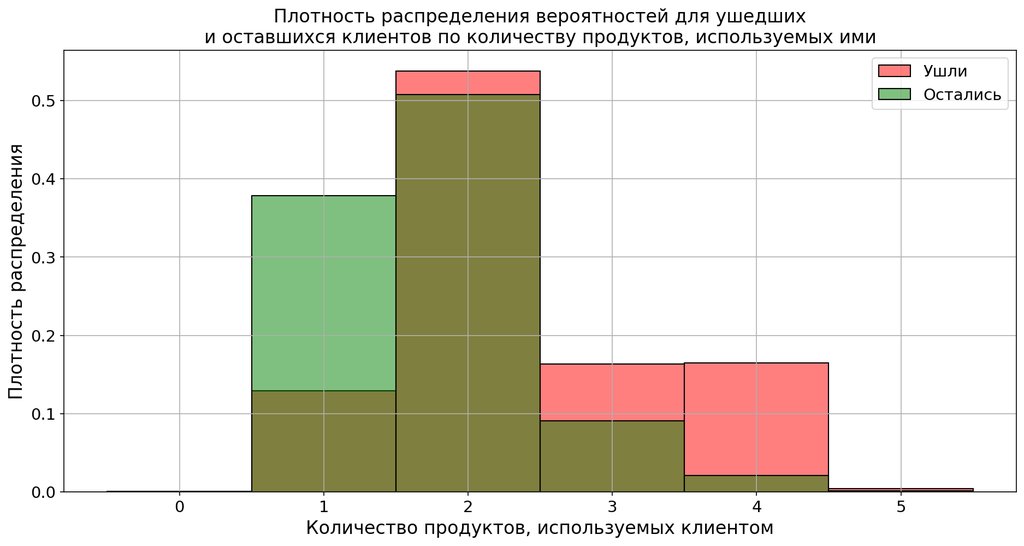

```python
plt.figure(figsize=(15, 7), dpi=150)
sns.histplot(data=data, hue='churn', x='products', discrete = True, stat='density', common_norm = False,
             palette={0: 'g', 1: 'r'})
plt.xticks(fontsize=14)
plt.yticks(fontsize=14)
plt.title('Плотность распределения вероятностей для ушедших\nи оставшихся клиентов по количеству продуктов, \
используемых ими',
          fontsize = 16)
plt.ylabel('Плотность распределения', fontsize = 16)
plt.xlabel('Количество продуктов, используемых клиентом', fontsize = 16)
plt.legend(loc='upper right', bbox_to_anchor=(1, 1), frameon=True, fontsize=14, labels=['Ушли', 'Остались'])
plt.grid(True)
plt.show()
```

**Вывод:** Наиболее отточными являются клиенты, имеющие 2 и более продуктов в банке.

#### Построим гистограмму плотности распределения вероятностей для ушедших и оставшихся клиентов по наличию кредитной карты

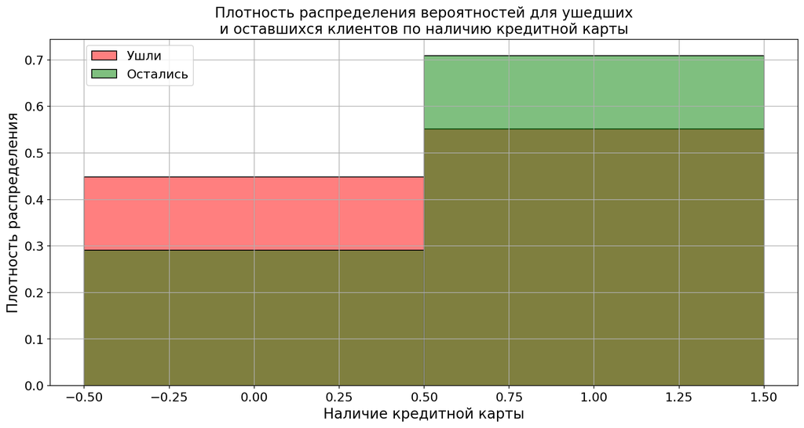

```python
plt.figure(figsize=(15, 7), dpi=150)
sns.histplot(data=data, hue='churn', x='credit_card', discrete = True, stat='density', common_norm = False,
             palette={0: 'g', 1: 'r'})
plt.xticks(fontsize=14)
plt.yticks(fontsize=14)
plt.title('Плотность распределения вероятностей для ушедших\nи оставшихся клиентов по наличию кредитной карты',
          fontsize = 16)
plt.ylabel('Плотность распределения', fontsize = 16)
plt.xlabel('Наличие кредитной карты', fontsize = 16)
plt.legend(loc='upper right', bbox_to_anchor=(0.2, 1), frameon=True, fontsize=14, labels=['Ушли', 'Остались'])
plt.grid(True)
plt.show()
```

**Вывод:** Наиболее отточными являются клиенты, не имеющие кредитной карты.

#### Построим гистограмму плотности распределения вероятностей для ушедших и оставшихся клиентов по наличию активности

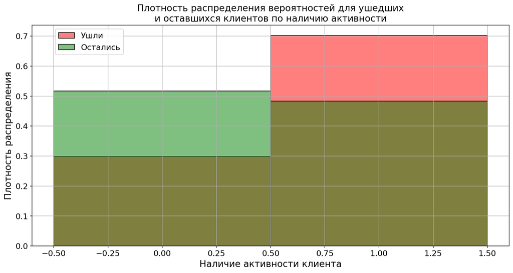

```python
plt.figure(figsize=(15, 7), dpi=150)
sns.histplot(data=data, hue='churn', x='last_activity', discrete = True, stat='density', common_norm = False,
             palette={0: 'g', 1: 'r'})
plt.xticks(fontsize=14)
plt.yticks(fontsize=14)
plt.title('Плотность распределения вероятностей для ушедших\nи оставшихся клиентов по наличию активности',
          fontsize = 16)
plt.ylabel('Плотность распределения', fontsize = 16)
plt.xlabel('Наличие активности клиента', fontsize = 16)
plt.legend(loc='upper right', bbox_to_anchor=(0.2, 1), frameon=True, fontsize=14, labels=['Ушли', 'Остались'])
plt.grid(True)
plt.show()
```

**Вывод:** Наиболее отточными являются активные клиенты банка.

#### Построим гистограмму плотности распределения вероятностей для ушедших и оставшихся клиентов по их оценочному доходу

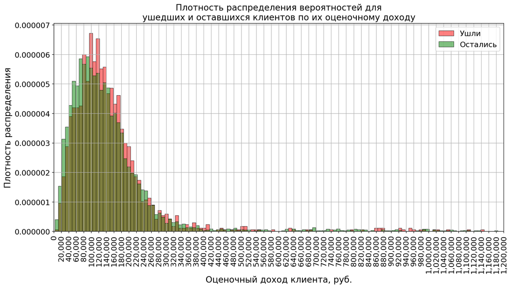

```python
plt.figure(figsize=(15, 7), dpi=150)
sns.histplot(data=data, hue='churn', x='est_salary', stat='density', common_norm = False, palette={0: 'g', 1: 'r'})
plt.ticklabel_format(style='plain')
formatter = ticker.FuncFormatter(lambda x, _: '{:,.0f}'.format(x))
plt.gca().xaxis.set_major_formatter(formatter)
plt.xticks(fontsize=14, rotation = 90)
plt.yticks(fontsize=14)
plt.title('Плотность распределения вероятностей для\nушедших и оставшихся клиентов по их оценочному доходу',
          fontsize = 16)
plt.ylabel('Плотность распределения', fontsize = 16)
plt.xlabel('Оценочный доход клиента, руб.', fontsize = 16)
plt.gca().xaxis.set_major_locator(MultipleLocator(20000))
plt.xlim(0, 1200000)
plt.legend(loc='upper right', bbox_to_anchor=(1, 1), frameon=True, fontsize=14, labels=['Ушли', 'Остались'])
plt.grid(True)
plt.show()
```

**Вывод:** Наиболее отточными являются клиенты, имеющие оценочный доход от 100 000 до 140 000 рублей и от 150 000 до 210 000 рублей.

### Построение матрицы корреляций и тепловой карты матрицы корреляций

#### Создадим отфильрованный датафрейм filtered_data, в котором удалим столбец userid для построения матрицы корреляций и тепловой карта матрицы корреляций

```python
filtered_data = data.drop('userid', axis=1)
filtered_data.head()
```

|  | score | city | gender | age | equity | balance | products | credit_card | last_activity | est_salary | churn |
| --- | --- | --- | --- | --- | --- | --- | --- | --- | --- | --- | --- |
| 0 | 850 | Рыбинск | Ж | 25 | 1 | 59,214.82 | 2 | 0 | 1 | 75,719.14 | 1 |
| 1 | 861 | Рыбинск | Ж | 37 | 5 | 850,594.33 | 3 | 1 | 0 | 86,621.77 | 0 |
| 2 | 892 | Рыбинск | Ж | 30 | 0 | NaN | 1 | 1 | 1 | 107,683.34 | 0 |
| 3 | 866 | Ярославль | Ж | 51 | 5 | 1,524,746.26 | 2 | 0 | 1 | 174,423.53 | 1 |
| 4 | 730 | Ярославль | М | 34 | 5 | 174.00 | 1 | 1 | 0 | 67,353.16 | 1 |

#### Построим матрицу корреляций correlation_matrix датафрейма filtered_data методом phik

```python
correlation_matrix = filtered_data.phik_matrix()
correlation_matrix
```

```
interval columns not set, guessing: ['score', 'age', 'equity', 'balance', 'products', 'credit_card', 'last_activity', 'est_salary', 'churn']
```

|  | score | city | gender | age | equity | balance | products | credit_card | last_activity | est_salary | churn |
| --- | --- | --- | --- | --- | --- | --- | --- | --- | --- | --- | --- |
| score | 1.00 | 0.09 | 0.07 | 0.03 | 0.53 | 0.17 | 0.31 | 0.21 | 0.05 | 0.39 | 0.23 |
| city | 0.09 | 1.00 | 0.01 | 0.09 | 0.06 | 0.04 | 0.22 | 0.07 | 0.03 | 0.17 | 0.02 |
| gender | 0.07 | 0.01 | 1.00 | 0.29 | 0.06 | 0.05 | 0.12 | 0.20 | 0.01 | 0.14 | 0.22 |
| age | 0.03 | 0.09 | 0.29 | 1.00 | 0.05 | 0.02 | 0.13 | 0.16 | 0.09 | 0.36 | 0.19 |
| equity | 0.53 | 0.06 | 0.06 | 0.05 | 1.00 | 0.00 | 0.44 | 0.22 | 0.05 | 0.29 | 0.35 |
| balance | 0.17 | 0.04 | 0.05 | 0.02 | 0.00 | 1.00 | 0.00 | 0.00 | 0.00 | 0.37 | 0.02 |
| products | 0.31 | 0.22 | 0.12 | 0.13 | 0.44 | 0.00 | 1.00 | 0.46 | 0.19 | 0.16 | 0.44 |
| credit_card | 0.21 | 0.07 | 0.20 | 0.16 | 0.22 | 0.00 | 0.46 | 1.00 | 0.05 | 0.04 | 0.20 |
| last_activity | 0.05 | 0.03 | 0.01 | 0.09 | 0.05 | 0.00 | 0.19 | 0.05 | 1.00 | 0.04 | 0.26 |
| est_salary | 0.39 | 0.17 | 0.14 | 0.36 | 0.29 | 0.37 | 0.16 | 0.04 | 0.04 | 1.00 | 0.05 |
| churn | 0.23 | 0.02 | 0.22 | 0.19 | 0.35 | 0.02 | 0.44 | 0.20 | 0.26 | 0.05 | 1.00 |

#### Построим тепловой карту матрицы корреляций датафрейма data

```
interval columns not set, guessing: ['score', 'age', 'equity', 'balance', 'products', 'credit_card', 'last_activity', 'est_salary', 'churn']
```

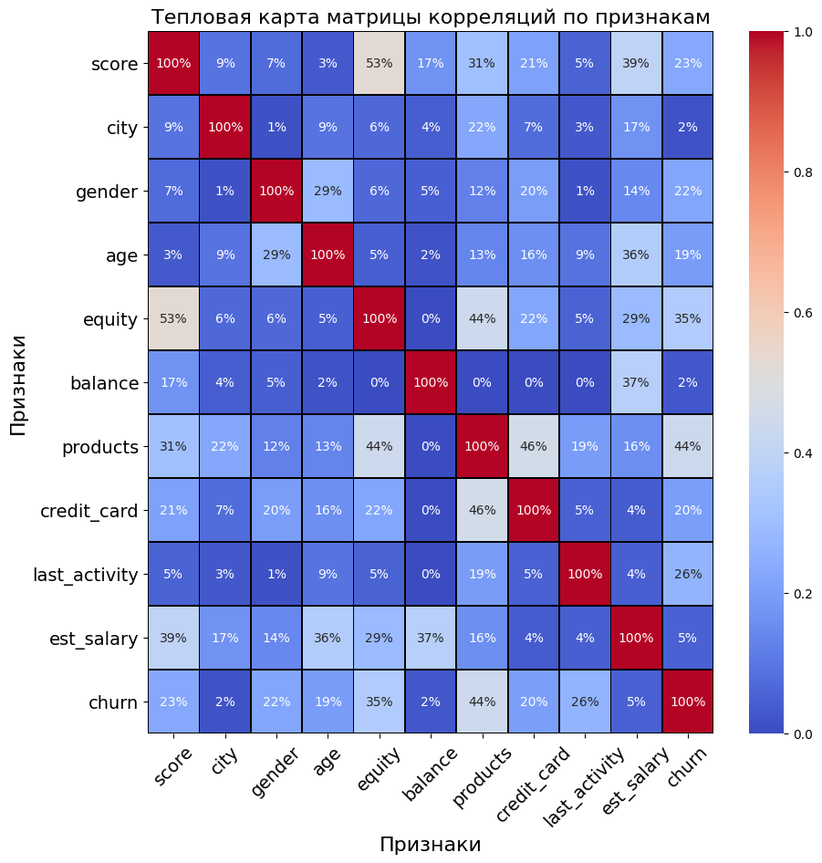

```python
corr_matrix = filtered_data.phik_matrix()
plt.figure(figsize=(10, 10), dpi = 100)
sns.heatmap(corr_matrix, annot=True, cmap='coolwarm', fmt='.0%', linewidths=0.5, linecolor='black')
plt.title('Тепловая карта матрицы корреляций по признакам', fontsize = 16)
plt.xticks(fontsize=14, rotation=45)
plt.yticks(fontsize=14, rotation=0)
plt.ylabel('Признаки', fontsize = 16)
plt.xlabel('Признаки', fontsize = 16)
plt.show()
```

#### Создадим матрицу корреляций correlation_matrix_churn, где будут отражена корреляций между фактом оттока и признаками клиентов

```python
correlation_matrix_churn = filtered_data.phik_matrix()['churn'].drop('churn')
correlation_matrix_churn
```

```
interval columns not set, guessing: ['score', 'age', 'equity', 'balance', 'products', 'credit_card', 'last_activity', 'est_salary', 'churn']
```

```
score           0.23
city            0.02
gender          0.22
age             0.19
equity          0.35
balance         0.02
products        0.44
credit_card     0.20
last_activity   0.26
est_salary      0.05
Name: churn, dtype: float64
```

#### Преобразуем матрицу корреляций correlation_matrix_churn в датафрейм correlation_df, отсортировав значения корреляции по убыванию

```python
correlation_df = correlation_matrix_churn.to_frame().reset_index()
correlation_df = correlation_df.sort_values(by='churn', ascending = False).reset_index(drop=True)
correlation_df
```

|  | index | churn |
| --- | --- | --- |
| 0 | products | 0.44 |
| 1 | equity | 0.35 |
| 2 | last_activity | 0.26 |
| 3 | score | 0.23 |
| 4 | gender | 0.22 |
| 5 | credit_card | 0.20 |
| 6 | age | 0.19 |
| 7 | est_salary | 0.05 |
| 8 | balance | 0.02 |
| 9 | city | 0.02 |

#### Постороим тепловую карту матрицы корреляций факта оттока от признаков клиентов

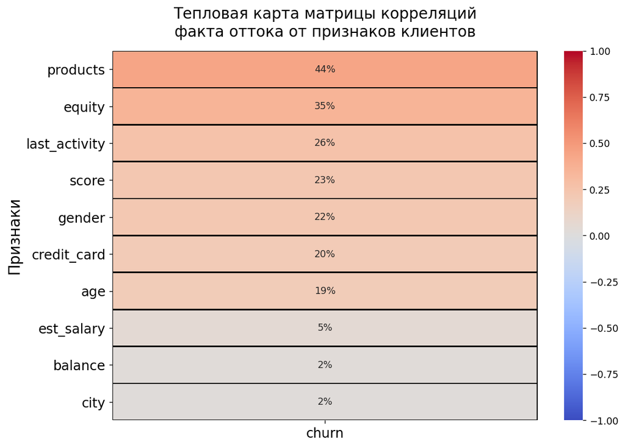

```python
plt.figure(figsize=(10, 7), dpi=125)
sns.heatmap(correlation_df.set_index('index'), annot=True, fmt='.0%', vmin=-1, vmax=1,
            center=0, cmap='coolwarm', linewidths=1, linecolor='black')
plt.title('Тепловая карта матрицы корреляций\nфакта оттока от признаков клиентов', fontsize=16, pad=15)
plt.xticks(fontsize=14)
plt.yticks(fontsize=14, rotation=0)
plt.ylabel('Признаки', fontsize=16)
plt.show()
```

**Выводы:** Больше всех на факт оттока влияет количество продуктов, которыми пользуется клиент банка - 44 %, затем идут количество баллов собственности - 35 %, наличие активности клиента - 26 %, балл кредитного скоринга - 23 %, пол клиента - 22%, наличие кредитной карты - 20 %, возраст клиента - 19 %. Корреляция остальных признаков с фактом оттока составляет 5 % и менее.

### Сегментация отточных клиентов на основе стратегических показателей

#### Оценка признаков для включения их в сегменты пользователей

##### Создадим отфильтрованный датафрейм filtered_data_products, где выведем клиентов, имеющих 2 и более продуктов

```python
filtered_data_products = data.query('products >= 2').reset_index(drop=True)
len(filtered_data_products)
```

```
6650
```

##### Посчитаем количество ушедших и оставшихся клиентов в датафрейме filtered_data_products, используя функцию count_of_data

```python
count_of_data(filtered_data_products, 'churn', 'Количество ушедших клиентов', 'Количество оставшихся клиентов', 1, 0)
```

```
Количество ушедших клиентов: 1583 или 23.8 %.
Количество оставшихся клиентов: 5067 или 76.2 %.
```

##### Создадим отфильтрованный датафрейм filtered_data_equity, где выведем клиентов, имеющих количество баллов собственности от 3 и более

```python
filtered_data_equity = data.query('equity >= 3').reset_index(drop=True)
len(filtered_data_equity)
```

```
5574
```

##### Посчитаем количество ушедших и оставшихся клиентов в датафрейме filtered_data_equity, используя функцию count_of_data

```python
count_of_data(filtered_data_equity, 'churn', 'Количество ушедших клиентов', 'Количество оставшихся клиентов', 1, 0)
```

```
Количество ушедших клиентов: 1470 или 26.37 %.
Количество оставшихся клиентов: 4104 или 73.63 %.
```

##### Создадим отфильтрованный датафрейм filtered_data_last_activity, где выведем только активных клиентов банка

```python
filtered_data_last_activity = data.query('last_activity == 1').reset_index(drop=True)
len(filtered_data_last_activity)
```

```
5215
```

##### Посчитаем количество ушедших и оставшихся клиентов в датафрейме filtered_data_last_activity, используя функцию count_of_data

```python
count_of_data(filtered_data_last_activity, 'churn', 'Количество ушедших клиентов', 'Количество оставшихся клиентов', 1, 0)
```

```
Количество ушедших клиентов: 1277 или 24.49 %.
Количество оставшихся клиентов: 3938 или 75.51 %.
```

##### Создадим отфильтрованный датафрейм filtered_data_score, где выведем клиентов имеющих баллы кредитного скоринга от 820 до 900

```python
filtered_data_score = data.query('score >= 820 & score <= 900').reset_index(drop=True)
len(filtered_data_score)
```

```
4203
```

##### Посчитаем количество ушедших и оставшихся клиентов в датафрейме filtered_data_score, используя функцию count_of_data

```python
count_of_data(filtered_data_score, 'churn', 'Количество ушедших клиентов', 'Количество оставшихся клиентов', 1, 0)
```

```
Количество ушедших клиентов: 1035 или 24.63 %.
Количество оставшихся клиентов: 3168 или 75.37 %.
```

##### Создадим отфильтрованный датафрейм filtered_data_gender, где выведем клиентов только мужского пола

```python
filtered_data_gender = data.query('gender == "М"').reset_index(drop=True)
len(filtered_data_gender)
```

```
4991
```

##### Посчитаем количество ушедших и оставшихся клиентов в датафрейме filtered_data_gender, используя функцию count_of_data

```python
count_of_data(filtered_data_gender, 'churn', 'Количество ушедших клиентов', 'Количество оставшихся клиентов', 1, 0)
```

```
Количество ушедших клиентов: 1183 или 23.7 %.
Количество оставшихся клиентов: 3808 или 76.3 %.
```

##### Создадим отфильтрованный датафрейм filtered_data_credit_card, где выведем только клиентов, не имеющих кредитную карту

```python
filtered_data_credit_card = data.query('credit_card == 0').reset_index(drop=True)
len(filtered_data_credit_card)
```

```
3190
```

##### Посчитаем количество ушедших и оставшихся клиентов в датафрейме filtered_data_credit_card, используя функцию count_of_data

```python
count_of_data(filtered_data_credit_card, 'churn', 'Количество ушедших клиентов', 'Количество оставшихся клиентов', 1, 0)
```

```
Количество ушедших клиентов: 816 или 25.58 %.
Количество оставшихся клиентов: 2374 или 74.42 %.
```

##### Создадим отфильтрованный датафрейм filtered_data_age, где выведем клиентов в возрасте от 25 до 35 лет и от 50 до 60 лет

```python
filtered_data_age = data.query('(age >= 25 & age <= 35 | age >= 50 & age <= 60)').reset_index(drop=True)
len(filtered_data_age)
```

```
4823
```

##### Посчитаем количество ушедших и оставшихся клиентов в датафрейме filtered_data_age, используя функцию count_of_data

```python
count_of_data(filtered_data_age, 'churn', 'Количество ушедших клиентов', 'Количество оставшихся клиентов', 1, 0)
```

```
Количество ушедших клиентов: 1133 или 23.49 %.
Количество оставшихся клиентов: 3690 или 76.51 %.
```

##### Создадим отфильтрованный датафрейм filtered_data_est_salary, где выведем клиентов с оценочным доходом от 100 000 до 140 000 рублей и от 150 000 до 210 000 рублей

```python
filtered_data_est_salary = data.query('(est_salary >= 100000 & est_salary <= 140000 | \
                                        est_salary >= 150000 & est_salary <= 210000)').reset_index(drop=True)
len(filtered_data_est_salary)
```

```
4041
```

##### Посчитаем количество ушедших и оставшихся клиентов в датафрейме filtered_data_est_salary, используя функцию count_of_data

```python
count_of_data(filtered_data_est_salary, 'churn', 'Количество ушедших клиентов', 'Количество оставшихся клиентов', 1, 0)
```

```
Количество ушедших клиентов: 839 или 20.76 %.
Количество оставшихся клиентов: 3202 или 79.24 %.
```

##### Создадим отфильтрованный датафрейм filtered_data_balance, где выведем клиентов, имеющих баланс на счете более 1 100 000 рублей

```python
filtered_data_balance = data.query('balance >= 1100000').reset_index(drop=True)
len(filtered_data_balance)
```

```
1614
```

##### Посчитаем количество ушедших и оставшихся клиентов в датафрейме filtered_data_balance, используя функцию count_of_data

```python
count_of_data(filtered_data_balance, 'churn', 'Количество ушедших клиентов', 'Количество оставшихся клиентов', 1, 0)
```

```
Количество ушедших клиентов: 663 или 41.08 %.
Количество оставшихся клиентов: 951 или 58.92 %.
```

##### Создадим отфильтрованный датафрейм filtered_data_city, где выведем клиентов, обслуживающихся в городе Ярославль

```python
filtered_data_city = data.query('city == "Ярославль"').reset_index(drop=True)
len(filtered_data_city)
```

```
5875
```

##### Посчитаем количество ушедших и оставшихся клиентов в датафрейме filtered_data_city, используя функцию count_of_data

```python
count_of_data(filtered_data_city, 'churn', 'Количество ушедших клиентов', 'Количество оставшихся клиентов', 1, 0)
```

```
Количество ушедших клиентов: 1117 или 19.01 %.
Количество оставшихся клиентов: 4758 или 80.99 %.
```

#### Выбор сегментов пользователей

Для проведения сегментации клиентов выберем ключевые признаки, которые сильнее всего всего влияют на отток. Учитывая коррелляционный анализ и количество ушедших клиентов, для начала сегментации выбираем количество продуктов, которыми пользуется клиент.

##### Посмотрим на отточный сегмент клиентов filtered_data_products, имеющих 2 и более продуктов в банке

```python
filtered_data_products.head()
```

|  | userid | score | city | gender | age | equity | balance | products | credit_card | last_activity | est_salary | churn |
| --- | --- | --- | --- | --- | --- | --- | --- | --- | --- | --- | --- | --- |
| 0 | 183012 | 850 | Рыбинск | Ж | 25 | 1 | 59,214.82 | 2 | 0 | 1 | 75,719.14 | 1 |
| 1 | 146556 | 861 | Рыбинск | Ж | 37 | 5 | 850,594.33 | 3 | 1 | 0 | 86,621.77 | 0 |
| 2 | 225363 | 866 | Ярославль | Ж | 51 | 5 | 1,524,746.26 | 2 | 0 | 1 | 174,423.53 | 1 |
| 3 | 202305 | 856 | Рыбинск | М | 56 | 4 | 863,687.24 | 3 | 1 | 0 | 156,619.80 | 0 |
| 4 | 177259 | 807 | Ярославль | Ж | 39 | 3 | 405,042.44 | 3 | 0 | 1 | 103,838.32 | 0 |

Из проведенных ранее расчетов размер датафрейма filtered_data_products составляет 6650 строк, количество ушедших клиентов: 1583 или 23.8 %, количество оставшихся клиентов: 5067 или 76.2 %. Чтобы сузить сегмент, добавим дополнительный признак. Согласно матрице корреляций - количество баллов собственности. Корреляция с фактом оттока составляет 35 %.

##### Создадим датафрейм segment_1, где выведем клиентов с количеством продуктов более двух и имеющие от 3 и более баллов собственности

```python
segment_1 = data.query('products >= 2 & equity >= 3').reset_index(drop=True)
print(f'Размер сегмента: {len(segment_1)}')
```

```
Размер сегмента: 4655
```

##### Посмотрим на полученный сегмент segment_1

```python
segment_1.head()
```

|  | userid | score | city | gender | age | equity | balance | products | credit_card | last_activity | est_salary | churn |
| --- | --- | --- | --- | --- | --- | --- | --- | --- | --- | --- | --- | --- |
| 0 | 146556 | 861 | Рыбинск | Ж | 37 | 5 | 850,594.33 | 3 | 1 | 0 | 86,621.77 | 0 |
| 1 | 225363 | 866 | Ярославль | Ж | 51 | 5 | 1,524,746.26 | 2 | 0 | 1 | 174,423.53 | 1 |
| 2 | 202305 | 856 | Рыбинск | М | 56 | 4 | 863,687.24 | 3 | 1 | 0 | 156,619.80 | 0 |
| 3 | 177259 | 807 | Ярославль | Ж | 39 | 3 | 405,042.44 | 3 | 0 | 1 | 103,838.32 | 0 |
| 4 | 218868 | 825 | Ярославль | Ж | 38 | 4 | 458,145.40 | 2 | 1 | 1 | 68,085.48 | 0 |

##### Посчитаем количество ушедших и оставшихся клиентов в датафрейме segment_1, используя функцию count_of_data

```python
count_of_data(segment_1, 'churn', 'Количество ушедших клиентов', 'Количество оставшихся клиентов', 1, 0)
```

```
Количество ушедших клиентов: 1316 или 28.27 %.
Количество оставшихся клиентов: 3339 или 71.73 %.
```

##### Сужаем сегмент segment_1 еще, добавив в него дополнительно только активных клиентов мужского пола

```python
segment_1 = data.query('products >= 2 & equity >= 3 & last_activity == 1 & gender == "М"').reset_index(drop=True)
print(f'Размер сегмента: {len(segment_1)}')
```

```
Размер сегмента: 1172
```

##### Посмотрим на полученный сегмент segment_1

```python
segment_1.head()
```

|  | userid | score | city | gender | age | equity | balance | products | credit_card | last_activity | est_salary | churn |
| --- | --- | --- | --- | --- | --- | --- | --- | --- | --- | --- | --- | --- |
| 0 | 172138 | 815 | Ярославль | М | 35 | 5 | 547,499.87 | 2 | 1 | 1 | 105,883.26 | 0 |
| 1 | 201837 | 922 | Ярославль | М | 67 | 3 | 366,599.61 | 2 | 1 | 1 | 246,523.17 | 0 |
| 2 | 164676 | 860 | Ярославль | М | 37 | 5 | 648,594.03 | 2 | 1 | 1 | 213,586.86 | 1 |
| 3 | 129225 | 809 | Ярославль | М | 42 | 4 | 371,454.10 | 2 | 1 | 1 | 93,829.85 | 0 |
| 4 | 156677 | 873 | Ярославль | М | 39 | 5 | 915,959.85 | 3 | 0 | 1 | 154,034.62 | 1 |

##### Посчитаем количество ушедших и оставшихся клиентов в датафрейме segment_1, используя функцию count_of_data

```python
count_of_data(segment_1, 'churn', 'Количество ушедших клиентов', 'Количество оставшихся клиентов', 1, 0)
```

```
Количество ушедших клиентов: 568 или 48.46 %.
Количество оставшихся клиентов: 604 или 51.54 %.
```

##### Создадим датафрейм segment_2, где выведем клиентов с количеством продуктов более двух и имеющие от 3 и более баллов собственности, только активных клиентов женского пола

```python
segment_2 = data.query('products >= 2 & equity >= 3 & last_activity == 1 & gender == "Ж"')
print(f'Размер сегмента: {len(segment_2)}')
```

```
Размер сегмента: 1296
```

##### Посмотрим на полученный сегмент segment_2

```python
segment_2.head()
```

|  | userid | score | city | gender | age | equity | balance | products | credit_card | last_activity | est_salary | churn |
| --- | --- | --- | --- | --- | --- | --- | --- | --- | --- | --- | --- | --- |
| 3 | 225363 | 866 | Ярославль | Ж | 51 | 5 | 1,524,746.26 | 2 | 0 | 1 | 174,423.53 | 1 |
| 6 | 177259 | 807 | Ярославль | Ж | 39 | 3 | 405,042.44 | 3 | 0 | 1 | 103,838.32 | 0 |
| 7 | 218868 | 825 | Ярославль | Ж | 38 | 4 | 458,145.40 | 2 | 1 | 1 | 68,085.48 | 0 |
| 12 | 132970 | 845 | Ярославль | Ж | 31 | 3 | 591,928.52 | 2 | 1 | 1 | 112,697.16 | 1 |
| 13 | 166357 | 837 | Рыбинск | Ж | 28 | 4 | 302,249.22 | 2 | 0 | 1 | 30,950.94 | 0 |

##### Посчитаем количество ушедших и оставшихся клиентов в датафрейме segment_2, используя функцию count_of_data

```python
count_of_data(segment_2, 'churn', 'Количество ушедших клиентов', 'Количество оставшихся клиентов', 1, 0)
```

```
Количество ушедших клиентов: 384 или 29.63 %.
Количество оставшихся клиентов: 912 или 70.37 %.
```

##### Создадим датафрейм segment_3, где выведем клиентов, не имеющих кредитной карты в возрасте от 25 до 35 лет

```python
segment_3 = data.query('credit_card == 0 & age >= 25 & age <= 35').reset_index(drop=True)
print(f'Размер сегмента: {len(segment_3)}')
```

```
Размер сегмента: 827
```

##### Посмотрим на полученный сегмент segment_3

```python
segment_3.head()
```

|  | userid | score | city | gender | age | equity | balance | products | credit_card | last_activity | est_salary | churn |
| --- | --- | --- | --- | --- | --- | --- | --- | --- | --- | --- | --- | --- |
| 0 | 183012 | 850 | Рыбинск | Ж | 25 | 1 | 59,214.82 | 2 | 0 | 1 | 75,719.14 | 1 |
| 1 | 166357 | 837 | Рыбинск | Ж | 28 | 4 | 302,249.22 | 2 | 0 | 1 | 30,950.94 | 0 |
| 2 | 220711 | 794 | Ростов | Ж | 26 | 2 | 147,487.39 | 2 | 0 | 1 | 24,912.88 | 0 |
| 3 | 129705 | 811 | Рыбинск | М | 34 | 2 | 129,799.35 | 1 | 0 | 0 | 96,242.71 | 1 |
| 4 | 140749 | 948 | Ярославль | Ж | 34 | 5 | 3,134,788.66 | 2 | 0 | 0 | 199,705.32 | 0 |

##### Посчитаем количество ушедших и оставшихся клиентов в датафрейме segment_3, используя функцию count_of_data

```python
count_of_data(segment_3, 'churn', 'Количество ушедших клиентов', 'Количество оставшихся клиентов', 1, 0)
```

```
Количество ушедших клиентов: 295 или 35.67 %.
Количество оставшихся клиентов: 532 или 64.33 %.
```

##### Создадим датафрейм segment_4, где выведем клиентов, не имеющих кредитной карты в возрасте от 50 до 60 лет

```python
segment_4 = data.query('credit_card == 0 & age >= 50 & age <= 60').reset_index(drop=True)
print(f'Размер сегмента: {len(segment_4)}')
```

```
Размер сегмента: 705
```

##### Посмотрим на полученный сегмент segment_4

```python
segment_4.head()
```

|  | userid | score | city | gender | age | equity | balance | products | credit_card | last_activity | est_salary | churn |
| --- | --- | --- | --- | --- | --- | --- | --- | --- | --- | --- | --- | --- |
| 0 | 225363 | 866 | Ярославль | Ж | 51 | 5 | 1,524,746.26 | 2 | 0 | 1 | 174,423.53 | 1 |
| 1 | 127034 | 922 | Рыбинск | Ж | 53 | 0 | NaN | 1 | 0 | 0 | 147,094.82 | 0 |
| 2 | 165331 | 846 | Ростов | Ж | 50 | 5 | 1,303,130.78 | 2 | 0 | 0 | 218,591.45 | 0 |
| 3 | 134157 | 779 | Ростов | М | 60 | 4 | 1,195,619.00 | 2 | 0 | 1 | 68,554.94 | 0 |
| 4 | 141891 | 815 | Ярославль | Ж | 50 | 4 | 407,936.79 | 3 | 0 | 1 | 89,622.11 | 0 |

##### Посчитаем количество ушедших и оставшихся клиентов в датафрейме segment_4, используя функцию count_of_data

```python
count_of_data(segment_4, 'churn', 'Количество ушедших клиентов', 'Количество оставшихся клиентов', 1, 0)
```

```
Количество ушедших клиентов: 250 или 35.46 %.
Количество оставшихся клиентов: 455 или 64.54 %.
```

##### Создадим датафрейм segment_5, где выведем клиентов, имеющие балл кредитного скоринга от 820 до 900 и баланс на счете более 1 100 000 рублей

```python
segment_5 = data.query('score >= 820 & score <= 900 & balance >= 1100000').reset_index(drop=True)
print(f'Размер сегмента: {len(segment_5)}')
```

```
Размер сегмента: 662
```

##### Посмотрим на полученный сегмент segment_5

```python
segment_5.head()
```

|  | userid | score | city | gender | age | equity | balance | products | credit_card | last_activity | est_salary | churn |
| --- | --- | --- | --- | --- | --- | --- | --- | --- | --- | --- | --- | --- |
| 0 | 225363 | 866 | Ярославль | Ж | 51 | 5 | 1,524,746.26 | 2 | 0 | 1 | 174,423.53 | 1 |
| 1 | 136651 | 876 | Ярославль | М | 40 | 5 | 2,307,947.36 | 2 | 0 | 0 | 287,010.61 | 0 |
| 2 | 221927 | 863 | Ростов | М | 39 | 5 | 1,461,423.33 | 1 | 0 | 1 | 221,699.52 | 0 |
| 3 | 199614 | 822 | Ярославль | М | 60 | 5 | 1,472,483.77 | 1 | 1 | 1 | 89,132.67 | 0 |
| 4 | 155573 | 893 | Рыбинск | Ж | 48 | 5 | 1,156,992.03 | 1 | 1 | 1 | 112,279.51 | 0 |

```python
count_of_data(segment_5, 'churn', 'Количество ушедших клиентов', 'Количество оставшихся клиентов', 1, 0)
```

```
Количество ушедших клиентов: 303 или 45.77 %.
Количество оставшихся клиентов: 359 или 54.23 %.
```

### Выводы по исследовательскому анализу данных

#### Общее описание данных

1. В датасете больше оставшихся клиентов по сравнению с ушедшими. Количество ушедших клиентов в датасете: 1819 или 18.24 %. Количество оставшихся клиентов: 8155 или 81.76 %.
2. В датасете представлены клиенты с баллом кредитного скоринга от 642 до 1000. Медианный балл кредитного скоринга составляет 853.
3. Больше всего клиентов из Ярославля (5875 или 58.90%). Далее идут такой город как Рыбинск (2683 или 26.90%) и Ростов (1416 или 14.20%).
4. Количество клиентов мужчин и женщин примерно одинаковое. Количетсво мужчин - 4991 или 50.04 %. Количество женщин - 4983 или 49.96 %.
5. Возраст клиентов составляет от 18 до 86 лет. Медианный возраст клиента - 40 лет.
6. Клиенты имеют от 0 до 9 баллов собственности. Медианное количество баллов собственности равно 3.
7. Баланс на счет клиентов составляет от 0 до 119,113,552.01 рублей. Медианный баланс на счете составляет 524295.33 рублей.
8. Клиенты имеют от 0 до 5 банковских продуктов. Медианное количество банковских продуктов равно 2.
9. Клиентов, которые имеют кредитную карту больше чем тех у которых ее нет. Количество клиентов у которых есть кредитная карта: 6784 или 68.02 %. Количество клиентов у которых нет кредитной карты: 3190 или 31.98 %.
10. Количество активных и не активных клиентов примерно одинаковое. Количество активных клиентов: 5215 или 52.29 %. Количество неактивных клиентов: 4759 или 47.71 %.
11. Оценочный доход клиента находится в диапазоне от 2546.30 до 1,395,064.45 рублей. Медианный оценочных доход клиента составляет 119,626.79 рублей.

#### Описание портретов ушедших и оставшихся клиентов

##### Описание портрета ушедшего клиента

1. Балл кредитного скоринга от 706 до 1000. Медианный балл кредитного скоринга составляет 866.
2. Больше всего клиентов из Ярославля (1117 или 61.41%). Далее идут такой город как Рыбинск (437 или 24.02%) и Ростов 265 или 14.57%).
3. Среди ушедших клиентов больше мужчин. Количество клиентов мужчин: 1183 или 65.04 %. Количество клиентов женщин: 636 или 34.96 %.
4. Возраст клиентов составляет от 18 до 79 лет. Медианный возраст клиента - 39 лет.
5. Клиенты имеют от 0 до 9 баллов собственности. Медианное количество баллов собственности равно 4.
6. Баланс на счет клиентов составляет от 0 до 64,866,210.15 рублей. Медианный баланс на счете составляет 783,908.90 рублей.
7. Клиенты имеют от 0 до 5 банковских продуктов. Медианное количество банковских продуктов равно 2.
8. Клиентов, которые имеют кредитную карту немного больше чем тех у которых ее нет. Количество клиентов у которых есть кредитная карта: 1003 или 55.14 %. Количество клиентов у которых нет кредитной карты: 816 или 44.86 %.
9. Количество активных клиентов намного больше чем неактивных. Количество активных клиентов: 1277 или 70.2 %. Количество неактивных клиентов: 542 или 29.8 %.
10. Оценочный доход клиента находится в диапазоне от 10,880.27 до 1,263,028.49 рублей. Медианный оценочных доход клиента составляет 125,395.22 рублей.

##### Описание портрета оставшегося клиента

1. Балл кредитного скоринга от 642 до 1000. Медианный балл кредитного скоринга составляет 848.
2. Больше всего клиентов из Ярославля (4758 или 58.34%). Далее идут такой город как Рыбинск (2246 или 27.54%) и Ростов (1151 или 14.11%).
3. Среди оставшихся клиентов больше женщин. Количество клиентов женщин: 4347 или 53.3 %. Количество клиентов мужчин: 3808 или 46.7 %.
4. Возраст клиентов составляет от 18 до 86 лет. Медианный возраст клиента - 40 лет.
5. Клиенты имеют от 0 до 9 баллов собственности. Медианное количество баллов собственности равно 3.
6. Баланс на счет клиентов составляет от 0 до 119,113,552.01 рублей. Медианный баланс на счете составляет 475,410.09 рублей.
7. Клиенты имеют от 1 до 5 банковских продуктов. Медианное количество банковских продуктов равно 2.
8. Клиентов, которые имеют кредитную карту намного больше чем тех у которых ее нет. Количество клиентов у которых есть кредитная карта: 5781 или 70.89 %. Количество клиентов у которых нет кредитной карты: 2374 или 29.11 %.
9. Количество активных клиентов немного меньше чем неактивных. Количество активных клиентов: 3938 или 48.29 %. Количество неактивных клиентов: 4217 или 51.71 %.
10. Оценочный доход клиента находится в диапазоне от 2,546.30 до 1,395,064.45 рублей. Медианный оценочных доход клиента составляет 118,227.60 рублей.

#### Анализ плотности распределения вероятностей по признакам

1. Наиболее отточными являются клиенты, имеющие баллы кредитного скоринга от 820 до 900.
2. Наиболее отточными являются клиенты банка из его представительства в Ярославле.
3. Наиболее отточными являются клиенты банка мужсокго пола.
4. На основе возраста можно выделить 2 группы наиболее отточных клиентов клиентов. Это 25 - 35 лет и 50 - 60 лет.
5. Наиболее отточными являются клиенты, имеющие от 3 и более баллов собственности.
6. Наиболее отточными являются клиенты, имеющие баланс на счете более 1 100 000 рублей.
7. Наиболее отточными являются клиенты, имеющие 2 и более продуктов в банке.
8. Наиболее отточными являются клиенты, не имеющие кредитной карты.
9. Наиболее отточными являются активные клиенты банка.
10. Наиболее отточными являются клиенты, имеющие оценочный доход клиента от 100 000 до 140 000 рублей и от 150 000 до 210 000 рублей.

#### Корелляционный анализ

Больше всех на факт оттока влияет количество продуктов, которыми пользуется клиент банка - 44%, затем идут количество баллов собственности - 35%, наличие активности клиента - 26%, балл кредитного скоринга - 23%, пол клиента - 22%, наличие кредитной карты - 20%, возраст клиента - 19%. Корреляция остальных признаков с фактом оттока составляет 5% и менее.

#### Сегментация отточных клиентов

На основе проведенного анализа были выделены 5 высокоотточных сегментов:

1. Сегмент 1 - 1172 клиентов. Данные клиенты мужского пола имеют 2 и более продуктов в банке, от 3 и более баллов собственности. Количество ушедших клиентов: 568 или 48.46 %.
2. Сегмент 2 - 1296 клиентов. Данные клиенты женского пола имеют 2 и более продуктов в банке, от 3 и более баллов собственности. Количество ушедших клиентов: 384 или 29.63 %.
3. Сегмент 3 - 827 клиентов. Данные клиенты не имеют кредитной карты в возрасте от 25 до 35 лет. Количество ушедших клиентов: 295 или 35.67%.
4. Сегмент 4 - 705 клиентов. Данные клиенты не имеют кредитной карты в возрасте от 50 до 60 лет. Количество ушедших клиентов: 250 или 35.46%.
5. Сегмент 5 - 662 клиента. Данные клиенты имеют баллы кредитного скоринга от 820 до 900 и баланс на счете более 1 100 000 рублей. Количество ушедших клиентов: 303 или 45.77%.

## Проверка статистических гипотез

### Средний оценочный доход ушедших и оставшихся клиентов одинаковый

#### Формулируем нулевую и альтернативную гипотезу

Нам необходимо сравнить средние значения двух независимых выборок.

Нулевая гипотеза (H0) - это предположение о том, что нет различий между средними значениями двух выборок. В случае t-теста, нулевая гипотеза утверждает, что среднее значение разницы между двумя выборками равно нулю. В данном случае это означает, что средний оценочный доход ушедших и осавшихся клиентов одинаковый.

Альтернативная гипотеза (H1) - это противоположное предположение о том, что существуют различия между средними значениями двух выборок. В t-тесте альтернативная гипотеза утверждает, что среднее значение разницы между двумя выборками не равно нулю. То есть средний оценочный доход ушедших и осавшихся клиентов отличается между собой.

Таким образом нулевая и альтернативная гипотезы будут выглядеть следующим образом:

Н0 (нулевая гипотеза) - средний оценочный доход ушедших и осавшихся клиентов одинаковый.

Н1 (альтернативная гипотеза) - средний оценочный доход ушедших и осавшихся клиентов отличается между собой.

#### Оценим размер выборки est_salary_churn и est_salary_remain

```python
est_salary_churn = filtered_data_churn['est_salary']
est_salary_remain = filtered_data_remain['est_salary']
print(f'Размер выборки est_salary_churn: {len(est_salary_churn)}')
print(f'Размер выборки est_salary_remain: {len(est_salary_remain)}')
```

```
Размер выборки est_salary_churn: 1819
Размер выборки est_salary_remain: 8155
```

#### Выведем описательную статистику по оценочному доходу ушедших клиентов

```python
est_salary_churn.describe()
```

```
count       1,819.00
mean      148,289.70
std       122,932.16
min        10,880.27
25%        83,196.61
50%       125,395.22
75%       175,985.39
max     1,263,028.49
Name: est_salary, dtype: float64
```

#### Выведем описательную статистику по оценочному доходу оставшихся клиентов

```python
est_salary_remain.describe()
```

```
count       8,155.00
mean      147,674.64
std       142,684.41
min         2,546.30
25%        73,445.55
50%       118,227.60
75%       173,960.92
max     1,395,064.45
Name: est_salary, dtype: float64
```

#### Оценим дисперсию выборок est_salary_churn и est_salary_remain

```python
est_salary_churn_var = np.var(est_salary_churn)
est_salary_remain_var = np.var(est_salary_remain)
print(f'Дисперсия выборки est_salary_churn: {est_salary_churn_var:,.2f}')
print(f'Дисперсия выборки est_salary_remain: {est_salary_remain_var:,.2f}')
```

```
Дисперсия выборки est_salary_churn: 15,104,008,500.90
Дисперсия выборки est_salary_remain: 20,356,342,952.42
```

#### Оценим распределение оценочных доходов ушедших и оставшихся клиентов

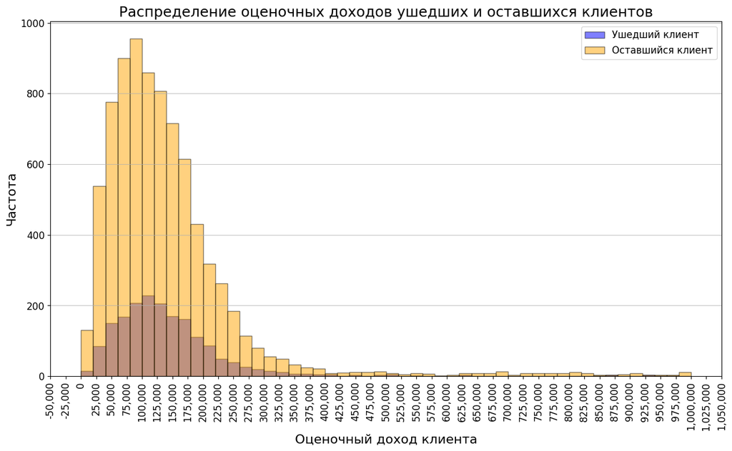

```python
min_value = 0
max_value = 1000000
plt.figure(figsize=(15, 8), dpi = 100)
plt.hist(est_salary_churn, bins=50, alpha=0.5, label='Ушедший клиент',
         color='blue', edgecolor='black', range=(min_value, max_value))
plt.hist(est_salary_remain, bins=50, alpha=0.5, label='Оставшийся клиент',
         color='orange', edgecolor='black', range=(min_value, max_value))
plt.title('Распределение оценочных доходов ушедших и оставшихся клиентов', fontsize = 18)
plt.xlabel('Оценочный доход клиента', fontsize = 16)
plt.ylabel('Частота', fontsize = 16)
plt.tick_params(axis='y', labelsize=12)
plt.tick_params(axis='x', labelsize=12, rotation = 90)
formatter = ticker.FuncFormatter(lambda x, _: '{:,.0f}'.format(x))
plt.gca().xaxis.set_major_formatter(formatter)
plt.gca().xaxis.set_major_locator(MultipleLocator(25000))
plt.legend(fontsize = 12)
plt.grid(axis='y', alpha=0.75)
plt.show()
```

**Вывод:** На первый взгляд средние похожи. Предварительный описательный анализ указывает, что выборки не равны в размерах. У них разные стандартные отклонения и дисперсии выборок различны (может повлиять на точность анализа).

- t-тест предполагает, что данные имеют нормальное распределение. Если данные не соответствуют этому предположению, то результаты теста могут быть недостоверными.
- t-тест предназначен для сравнения средних значений двух независимых выборок. Поэтому важно, чтобы в каждой группе (выборке) было достаточное количество наблюдений и они были равномерно распределены.
- t-тест предполагает, что выборки, которые сравниваются, являются независимыми. Если наблюдения в одной выборке зависят от наблюдений в другой выборке (например, в случае последовательных временных точек), то необходимо использовать другие статистические методы.
- Для получения достоверных результатов t-теста необходимо, чтобы размер каждой выборки был достаточно большим. Минимальные требования к размеру выборки зависят от уровня значимости.
- t-тест чувствителен к выбросам в данных, поэтому важно убедиться, что в данных нет экстремальных значений, которые могут исказить результаты.
- t-тест предполагает, что дисперсии (разбросы) данных в каждой выборке примерно одинаковы. Если это не так, то следует использовать параметр equal_var равным False.

С учетом данных обстоятельств, после проверки данных для оценки гипотезы будем применять t-критерий Стьюдента. Соотвественно, мы можем получить два ответа "Отвергаем нулевую гипотезу" и "Не получилось отвергнуть нулевую гипотезу". Установим уровень статистической значимости в 1% (alpha = 0.01).

#### Проводим ttest для двух выборок, в качестве альтернативной используем двустороннюю гипотезу «в обе стороны»

```python
alpha = 0.01

results = st.ttest_ind(
    est_salary_churn,
    est_salary_remain,
    equal_var=False,
    alternative='two-sided')

print('p-значение:', results.pvalue)

if results.pvalue < alpha:
    print('Отвергаем нулевую гипотезу')
else:
    print('Не получилось отвергнуть нулевую гипотезу')
```

```
p-значение: 0.8515799588935961
Не получилось отвергнуть нулевую гипотезу
```

**Вывод:** Не получилось отвергнуть нулевую гипотезу. Таким образом, при уровне статистической значимости в 1 % средний оценочный доход ушедших и оставшихся клиентов одинаковый.

### Средний баланс на счёте ушедших и оставшихся клиентов одинаковый

#### Формулируем нулевую и альтернативную гипотезу

Нам необходимо сравнить средние значения двух независимых выборок.

Таким образом нулевая и альтернативная гипотезы будут выглядеть следующим образом:

Н0 (нулевая гипотеза) - средний баланс на счёте ушедших и оставшихся клиентов одинаковый.

Н1 (альтернативная гипотеза) - средний баланс на счёте ушедших и оставшихся клиентов отличается между собой.

#### Оценим размер выборки balance_churn и balance_remain

```python
balance_churn = filtered_data_churn['balance'].dropna()
balance_remain = filtered_data_remain['balance'].dropna()
print(f'Размер выборки est_salary_churn: {len(balance_churn)}')
print(f'Размер выборки est_salary_remain: {len(balance_remain)}')
```

```
Размер выборки est_salary_churn: 1806
Размер выборки est_salary_remain: 5889
```

#### Выведем описательную статистику по балансу на счете ушедших клиентов

```python
balance_churn.describe()
```

```
count        1,806.00
mean     1,134,458.21
std      2,034,445.55
min              6.00
25%        387,482.16
50%        783,908.90
75%      1,348,127.55
max     64,866,210.15
Name: balance, dtype: float64
```

#### Выведем описательную статистику по балансу на счете оставшихся клиентов

```python
balance_remain.describe()
```

```
count         5,889.00
mean        733,031.63
std       1,953,952.48
min               0.00
25%         279,654.70
50%         475,410.09
75%         853,826.36
max     119,113,552.01
Name: balance, dtype: float64
```

#### Оценим дисперсию выборок balance_churn и balance_remain

```python
balance_churn_var = np.var(balance_churn)
balance_remain_var = np.var(balance_remain)
print(f'Дисперсия выборки balance_churn: {balance_churn_var:,.2f}')
print(f'Дисперсия выборки balance_remain: {balance_remain_var:,.2f}')
```

```
Дисперсия выборки balance_churn: 4,136,676,902,828.09
Дисперсия выборки balance_remain: 3,817,281,989,339.14
```

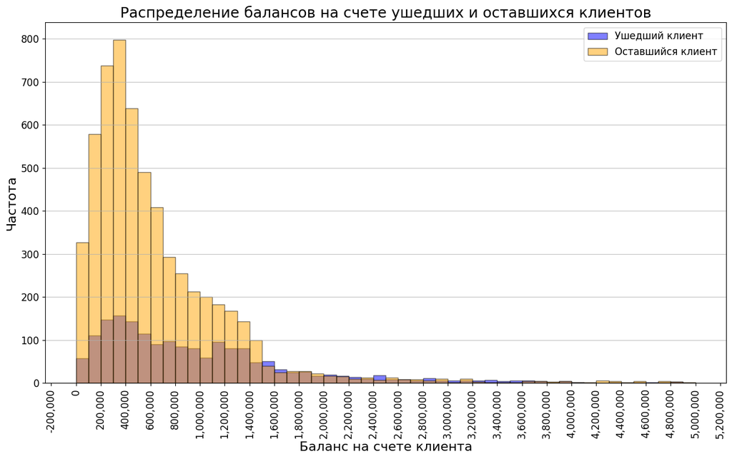

```python
min_value = 0
max_value = 5000000
plt.figure(figsize=(15, 8), dpi = 100)
plt.hist(balance_churn, bins=50, alpha=0.5, label='Ушедший клиент',
         color='blue', edgecolor='black', range=(min_value, max_value))
plt.hist(balance_remain, bins=50, alpha=0.5, label='Оставшийся клиент',
         color='orange', edgecolor='black', range=(min_value, max_value))
plt.title('Распределение балансов на счете ушедших и оставшихся клиентов', fontsize = 18)
plt.xlabel('Баланс на счете клиента', fontsize = 16)
plt.ylabel('Частота', fontsize = 16)
plt.tick_params(axis='y', labelsize=12)
plt.tick_params(axis='x', labelsize=12, rotation = 90)
formatter = ticker.FuncFormatter(lambda x, _: '{:,.0f}'.format(x))
plt.gca().xaxis.set_major_formatter(formatter)
plt.gca().xaxis.set_major_locator(MultipleLocator(200000))
plt.legend(fontsize = 12)
plt.grid(axis='y', alpha=0.75)
plt.show()
```

- t-тест предполагает, что данные имеют нормальное распределение. Если данные не соответствуют этому предположению, то результаты теста могут быть недостоверными.
- t-тест предназначен для сравнения средних значений двух независимых выборок. Поэтому важно, чтобы в каждой группе (выборке) было достаточное количество наблюдений и они были равномерно распределены.
- t-тест предполагает, что выборки, которые сравниваются, являются независимыми. Если наблюдения в одной выборке зависят от наблюдений в другой выборке (например, в случае последовательных временных точек), то необходимо использовать другие статистические методы.
- Для получения достоверных результатов t-теста необходимо, чтобы размер каждой выборки был достаточно большим. Минимальные требования к размеру выборки зависят от уровня значимости.
- t-тест чувствителен к выбросам в данных, поэтому важно убедиться, что в данных нет экстремальных значений, которые могут исказить результаты.
- t-тест предполагает, что дисперсии (разбросы) данных в каждой выборке примерно одинаковы. Если это не так, то следует использовать параметр equal_var равным False.

С учетом данных обстоятельств, после проверки данных для оценки гипотезы будем применять t-критерий Стьюдента. Соотвественно, мы можем получить два ответа "Отвергаем нулевую гипотезу" и "Не получилось отвергнуть нулевую гипотезу". Установим уровень статистической значимости в 1% (alpha = 0.01).

#### Проводим ttest для двух выборок, в качестве альтернативной используем двустороннюю гипотезу «в обе стороны»

```python
alpha = 0.01

results = st.ttest_ind(
    balance_churn,
    balance_remain,
    equal_var=False,
    alternative='two-sided')

print('p-значение:', results.pvalue)

if results.pvalue < alpha:
    print('Отвергаем нулевую гипотезу')
else:
    print('Не получилось отвергнуть нулевую гипотезу')
```

```
p-значение: 1.7317408579113568e-13
Отвергаем нулевую гипотезу
```

**Вывод:** Отвергаем нулевую гипотезу. Таким образом, при уровне статистической значимости в 1 % средний баланс на счёте ушедших и оставшихся клиентов отличается между собой.

## Выводы и рекомендации для заказчика

### Проведенная работа над данными

1. Изучена общая информация о представленных данных.
2. В данных были проанализированы пропуски и дубликаты.
3. Для дальнейшего анализа в датафреймах были изменены типы данных в некоторых столбцах и приведены к нижнему регистру некоторые столбцы в данных.

### Выводы по итогу исследовательского анализа данных

#### Общее описание данных

1. В датасете больше оставшихся клиентов по сравнению с ушедшими. Количество ушедших клиентов в датасете: 1819 или 18.24 %.
2. В датасете представлены клиенты с баллом кредитного скоринга от 642 до 1000.
3. Больше всего клиентов из Ярославля (5875 или 58.90%).
4. Количество клиентов мужчин и женщин примерно одинаковое.
5. Возраст клиентов составляет от 18 до 86 лет.
6. Клиенты имеют от 0 до 9 баллов собственности.
7. Баланс на счет клиентов составляет от 0 до 119,113,552.01 рублей.
8. Клиенты имеют от 0 до 5 банковских продуктов.
9. Клиентов, которые имеют кредитную карту больше чем тех у которых ее нет.
10. Количество активных и не активных клиентов примерно одинаковое.
11. Оценочный доход клиента находится в диапазоне от 2546.30 до 1,395,064.45 рублей.

#### Описание портретов ушедших и оставшихся клиентов

##### Описание портрета ушедшего клиента

1. Балл кредитного скоринга от 706 до 1000.
2. Больше всего клиентов из Ярославля (1117 или 61.41%).
3. Среди ушедших клиентов больше мужчинн.
4. Возраст клиентов составляет от 18 до 79 лет.
5. Клиенты имеют от 0 до 9 баллов собственности.
6. Баланс на счет клиентов составляет от 0 до 64,866,210.15 рублей.
7. Клиенты имеют от 0 до 5 банковских продуктов.
8. Клиентов, которые имеют кредитную карту немного больше чем тех у которых ее нет.
9. Количество активных клиентов намного больше чем неактивных.
10. Оценочный доход клиента находится в диапазоне от 10,880.27 до 1,263,028.49 рублей.

##### Описание портрета оставшегося клиента

1. Балл кредитного скоринга от 642 до 1000.
2. Больше всего клиентов из Ярославля (4758 или 58.34%).
3. Среди оставшихся клиентов больше женщин.
4. Возраст клиентов составляет от 18 до 86 лет.
5. Клиенты имеют от 0 до 9 баллов собственности.
6. Баланс на счет клиентов составляет от 0 до 119,113,552.01 рублей.
7. Клиенты имеют от 1 до 5 банковских продуктов.
8. Клиентов, которые имеют кредитную карту намного больше чем тех у которых ее нет.
9. Количество активных клиентов немного меньше чем неактивных.
10. Оценочный доход клиента находится в диапазоне от 2,546.30 до 1,395,064.45 рублей.

#### Сегментация отточных клиентов

На основе проведенного анализа были выделены 5 высокоотточных сегментов:

1. Сегмент 1 - 1172 клиентов. Данные клиенты мужского пола имеют 2 и более продуктов в банке, от 3 и более баллов собственности. Количество ушедших клиентов: 568 или 48.46 %.
2. Сегмент 2 - 1296 клиентов. Данные клиенты женского пола имеют 2 и более продуктов в банке, от 3 и более баллов собственности. Количество ушедших клиентов: 384 или 29.63 %.
3. Сегмент 3 - 827 клиентов. Данные клиенты не имеют кредитной карты в возрасте от 25 до 35 лет. Количество ушедших клиентов: 295 или 35.67%.
4. Сегмент 4 - 705 клиентов. Данные клиенты не имеют кредитной карты в возрасте от 50 до 60 лет. Количество ушедших клиентов: 250 или 35.46%.
5. Сегмент 5 - 662 клиента. Данные клиенты имеют баллы кредитного скоринга от 820 до 900 и баланс на счете более 1 100 000 рублей. Количество ушедших клиентов: 303 или 45.77%.

### Выводы по проверке гипотез

1. При уровне статистической значимости в 1 % средний оценочный доход ушедших и оставшихся клиентов одинаковый.
2. При уровне статистической значимости в 1 % средний баланс на счёте ушедших и оставшихся клиентов отличается между собой.

### Рекомендации отделу маркетинга банка

1. Активнее предлагать молодым (от 25 до 35 лет) и старым клиентам (от 50 до 60 лет) кредитные карты.
2. Предлагать надежным заемщикам более выгодные условия по кредитам чем в других банках.
3. Активнее предлагать действующим клиентам действующие банковские продукты.
4. Для удержания клиентом с большим баланском на счете (более 1 миллиона рублей) предлагать выгодные инвестиционные предложения в частности на фондовом рынке и выгодные вклады с высокой процентной ставкой.
5. Развивать программу лояльности по дебетовым картам.